# M2 Thesis - Imitation

Erik Morris

Université Paris Cité

May 15, 2024

# 1 Overview

Measures have been limited to: Spectral moments at the midpoint, durations (burst for stop), and VOT.

# 2 Load Packages

```r
loadPackage <- c('tidyverse', 'lmerTest', 'lme4', 'knitr', 'kableExtra', 'patchwork', 'ragg')
for(a in loadPackage){
  library(a, character.only = TRUE)
}
```

# 3 Load Data

Praat outputs encoding at UTF-16

```r
# French Participants French
dfFrench <- read.csv("Fr_Measures_Block.csv", header = TRUE, fileEncoding = "UTF-16")

# French Participants Greek
dfFrGreek <- read.csv("FR_GR_head.csv", header = TRUE, fileEncoding = "UTF-16")

# Print the frames for quick checking
dfFrench
```

| Speaker | Consonant | CoG | SD | Kurt | Skew | CoG_mid | SD_mid | Kurt_mid | Skew_mid | FricBurst_dur | Vowel | F1_Onset | F2_Onset | F3_Onset | F1_Mid | F2_Mid | F3_Mid | In_Word | Closure | VOT | Burst_Amp | Block |
| --- | --- | --- | --- | --- | --- | --- | --- | --- | --- | --- | --- | --- | --- | --- | --- | --- | --- | --- | --- | --- | --- | --- |
| FF01 | d | 1084.43894 | 2558.4582 | 9.995346e+00 | 3.2863719068 | NA | NA | NA | NA | 1.550534e-02 | a | 516.9119391063313 | 1803.531449977469 | 2883.8715643192095 | 705.8979705968222 | 1797.443111712416 | 2767.339544800722 | dater | 0.10274452 | -0.10274452 | 7.92349524 | 0 |
| FF01 | d | 1558.44206 | 2713.5474 | 4.467624e+00 | 2.2916638510 | NA | NA | NA | NA | 1.198862e-02 | o | 357.22543314217205 | 1529.0245061906048 | 2931.5725499047307 | 437.92711842878987 | 911.6305893506999 | 2918.495700822813 | dauber | 0.09104566 | -0.09104566 | 7.17547647 | 0 |
| FF01 | g | 1548.94423 | 3101.2286 | 3.736170e+00 | 2.2932294915 | NA | NA | NA | NA | 1.912406e-02 | o | 320.46016745640225 | 1130.4595285039472 | 2715.3688259473124 | 409.59644336456756 | 971.788970513016 | 2823.441037894723 | gober | 0.09413929 | -0.09413929 | 5.93903153 | 0 |
| FF01 | g | 1682.05390 | 2201.0146 | 9.018977e+00 | 2.5266455241 | NA | NA | NA | NA | 2.324349e-02 | e | 328.17772504247114 | 2266.4998872586384 | 3473.6708658089974 | 415.22829551773754 | 2340.5941948256095 | 3185.7341790549563 | guettais | 0.08146626 | -0.08146626 | 7.83303299 | 0 |
| FF01 | d | 519.97665 | 1127.3188 | 2.126734e+01 | 4.2002278283 | NA | NA | NA | NA | 1.619065e-02 | u | 279.91411423698105 | 1533.0970993126255 | 2929.0710447834995 | 332.00525189157815 | 1357.4294525243213 | 2922.232094656991 | doucet | 0.04901830 | -0.04901830 | 4.31449167 | 0 |
| FF01 | g | 576.45188 | 1490.9388 | 3.327183e+01 | 5.3475316854 | NA | NA | NA | NA | 2.231629e-02 | e | 341.9735113962137 | 2436.5294990547222 | 3138.028459908061 | 425.8921271278376 | 2405.968140305026 | 3030.75482475279 | gaiement | 0.04776938 | -0.04776938 | -1.53569118 | 0 |
| FF01 | t | 6576.66972 | 4334.3995 | -1.024381e+00 | -0.0091553745 | NA | NA | NA | NA | 3.558903e-02 | e | 403.8241111924403 | 2164.5544452249005 | 3016.171091639325 | 432.0965046202113 | 2265.4111489301104 | 3051.9543532826606 | téter | 0.05531472 | 0.03137666 | -2.71255811 | 0 |
| FF01 | t | 1530.62386 | 3207.5733 | 5.598885e+00 | 2.5961274834 | NA | NA | NA | NA | 2.138093e-02 | a | 606.5584560332651 | 1793.5573389546526 | 3006.991462408878 | 745.4932592701614 | 1672.886384817491 | 2915.9035022390985 | taper | 0.04332010 | 0.01975477 | 5.02999603 | 0 |
| FF01 | f | 9214.04044 | 5147.3038 | -1.274743e+00 | -0.4679970532 | 11378.5229 | 3411.7598 | -1.765685435 | 3.117746257 | 1.040086e+02 | o | 506.51740928592864 | 1121.914802118808 | 2934.9848559156053 | 500.1534850170549 | 985.1442252385199 | 2903.221331280378 | focale | NA | NA | NA | 0 |
| FF01 | t | 3520.09197 | 3600.2615 | -3.838868e-01 | 0.8524077013 | NA | NA | NA | NA | 3.547648e-02 | ɔ | 453.0864492514205 | 1404.5300758104893 | 2913.026991622535 | 478.18356574923257 | 1481.635791367237 | 2927.467436541081 | tonnais | 0.03302017 | 0.02914032 | 1.01415955 | 0 |

[output cut: 990 more lines]

```r
dfFrGreek
```

| Speaker | Consonant | CoG | SD | Kurt | Skew | CoG_mid | SD_mid | Kurt_mid | Skew_mid | FricBurst_dur | Vowel | F1_Onset | F2_Onset | F3_Onset | F1_Mid | F2_Mid | F3_Mid | In_Word | Closure | VOT | Burst_Amp | Substituted |
| --- | --- | --- | --- | --- | --- | --- | --- | --- | --- | --- | --- | --- | --- | --- | --- | --- | --- | --- | --- | --- | --- | --- |
| FF10 | ɣ | 953.4263 | 1386.5334 | 4.025994e+01 | 5.800586246 | 799.8282 | 1867.3275 | 4.913468169 | 2.545553e+01 | 81.60787611 | a | 524.9625 | 1000.6088 | 3124.815 | 772.5260133012182 | 1134.4694725262345 | 2848.3688580530616 | γάτα | NA | NA | NA | NA |
| FF10 | ð | 924.2309 | 2460.3082 | 1.086226e+01 | 3.394018282 | 6619.6444 | 4615.8914 | -0.138179441 | -1.073725e+00 | 68.22176820 | i | 341.2576 | 2322.8457 | 3190.511 | 380.29688920563336 | 2403.057337918098 | 3173.7433847521133 | δίδα | NA | NA | NA | z |
| FF10 | θ | 3664.2475 | 3764.2178 | -7.589068e-01 | 0.588636776 | 8075.7336 | 2745.3173 | 0.403066166 | 3.207230e-01 | 97.85437065 | i | 328.2929 | 2484.6341 | 3190.985 | 355.35791205666203 | 2587.278145339854 | 3134.9048811521257 | θύτης | NA | NA | NA | s |
| FF10 | ç | 4489.1399 | 1865.8365 | 1.699185e+00 | 0.671858222 | 5213.9663 | 2166.2179 | 0.783636164 | 1.118452e+00 | 148.49508791 | i | 314.4771 | 2431.3132 | 3243.634 | 313.8156046867018 | 2533.112261132269 | 2717.126189890945 | χύτης | NA | NA | NA | NA |
| FF10 | ç | 3803.5109 | 1810.9367 | 1.057079e+00 | 0.482922351 | 4665.1228 | 1750.0562 | 1.240240677 | 2.345212e+00 | 177.59352280 | i | 300.9403 | 2832.9061 | 3818.416 | 320.46655945763035 | 2747.854753001567 | 3906.4792811826296 | χύνει | NA | NA | NA | NA |
| FF10 | θ | 1979.2719 | 2762.1966 | 2.262831e+00 | 1.770935612 | 8638.3481 | 2167.9142 | -0.403992175 | -3.901378e-01 | 171.50783388 | i | 356.8318 | 2235.1806 | 3103.278 | 388.3080887724761 | 2504.0714503468685 | 3110.699817482047 | θύμα | NA | NA | NA | s |
| FF10 | ʝ | 479.7347 | 919.9910 | 6.538109e+01 | 6.632053861 | 3080.9838 | 2336.9328 | 1.365760308 | 2.728453e+00 | 98.75211870 | i | 334.8225 | 2161.3844 | 3020.901 | 400.1837660793749 | 2132.068475956189 | 3156.950053608667 | γίδα | NA | NA | NA | NA |
| FF10 | ʝ | 464.9459 | 1441.6368 | 3.415382e+01 | 5.687691275 | 958.3462 | 2511.2050 | 3.227563303 | 9.818566e+00 | 104.34939186 | e | 366.4757 | 2541.4198 | 3375.820 | 686.4616024141355 | 2269.800047066833 | 3091.45072973304 | γέλα | NA | NA | NA | NA |
| FF10 | ð | 553.8015 | 1535.1502 | 3.198255e+01 | 5.312040467 | 4589.2121 | 4636.9842 | 0.279221477 | -1.670865e+00 | 103.12404180 | u | 326.4265 | 1565.3478 | 3500.540 | 363.7401895214817 | 867.9842360506618 | 2554.2754483990007 | δούλα | NA | NA | NA | z |
| FF10 | ɣ | 661.1968 | 575.8234 | 1.814986e+02 | 10.437748789 | 948.7822 | 1533.5960 | 4.459130871 | 2.235223e+01 | 108.68671127 | a | 579.1260 | 1076.1728 | 2852.128 | 710.8508600001021 | 1355.295987789159 | 2919.8405793383586 | γάρος | NA | NA | NA | NA |

[output cut: 990 more lines]

# 4 Prepare the data

## 4.1 Factors

```r
# Convert categorical variables to factors
fac_list <- c("Consonant", "Vowel", "Block", "is_sub")
## L1 French doing French: Consonant, Vowel, Block
dfFrench <- dfFrench %>% mutate(across(any_of(fac_list), as.factor))
## L1 French doing Greek: Consonant, Vowel, Is_sub
dfFrGreek <- dfFrGreek %>% mutate(is_sub = case_when(Substituted %in% NA ~ 0, TRUE ~ 1)) %>%
  mutate(across(any_of(fac_list), as.factor))

# Reorder the levels of some factors
dfFrench$Consonant <- factor(dfFrench$Consonant, levels = c("t","d","k","g","f","v"))
dfFrGreek$Consonant <- factor(dfFrGreek$Consonant, levels = c("c","ɟ","θ","ð","ç","ʝ","x","ɣ"))
```

## 4.2 Time conversion to ms

```r
# Convert Stop time measures to ms (because I forgot to in the Praat script)
dfFrench <- dfFrench %>%
  mutate(FricBurst_dur = case_when(Consonant %in% c("t","d","c","ɟ","k","g") ~ FricBurst_dur * 1000,
                                   TRUE ~ FricBurst_dur),
         Closure = case_when(Consonant %in% c("t","d","c","ɟ","k","g") ~ Closure * 1000,
                             TRUE ~ Closure),
         VOT = case_when(Consonant %in% c("t","d","c","ɟ","k","g") ~ VOT * 1000,
                         TRUE ~ VOT))

dfFrGreek <- dfFrGreek %>%
  mutate(FricBurst_dur = case_when(Consonant %in% c("t","d","c","ɟ","k","g") ~ FricBurst_dur * 1000,
                                   TRUE ~ FricBurst_dur),
         Closure = case_when(Consonant %in% c("t","d","c","ɟ","k","g") ~ Closure * 1000,
                             TRUE ~ Closure),
         VOT = case_when(Consonant %in% c("t","d","c","ɟ","k","g") ~ VOT * 1000,
                         TRUE ~ VOT))
```

## 4.3 Calculations of measures

### 4.3.1 Separate the Blocks

```r
# L1 French doing French
dfFr_base <- dfFrench %>% filter(Block==0)
dfFr_imit <- dfFrench %>% filter(Block!=0 & Block!=4)
```

```r
# L1 French doing French
dfFr_base <- dfFr_base %>% group_by(Speaker, Consonant) %>%
  reframe(count = n(), mean_cog = mean(CoG), min_cog = min(CoG), max_cog = max(CoG),
          mean_sd = mean(SD), min_sd = min(SD), max_sd = max(SD),
          mean_kurt = mean(Kurt), min_kurt = min(Kurt), max_kurt = max(Kurt),
          mean_skew = mean(Skew), min_skew = min(Skew), max_skew = max(Skew),
          mean_cog_mid = mean(CoG_mid), min_cog_mid = min(CoG_mid), max_cog_mid = max(CoG_mid),
          mean_sd_mid = mean(SD_mid), min_sd_mid = min(SD_mid), max_sd_mid = max(SD_mid),
          mean_kurt_mid = mean(Kurt_mid), min_kurt_mid = min(Kurt_mid), max_kurt_mid = max(Kurt_mid),
          mean_skew_mid = mean(Skew_mid), min_skew_mid = min(Skew_mid), max_skew_mid = max(Skew_mid),
          mean_dur = mean(FricBurst_dur), min_dur = min(FricBurst_dur), max_dur = max(FricBurst_dur),
          mean_closure = mean(Closure), min_closure = min(Closure), max_closure = max(Closure),
          mean_vot = mean(VOT), min_vot = min(VOT), max_vot = max(VOT),
          mean_amp = mean(Burst_Amp), min_amp = min(Burst_Amp), max_amp = max(Burst_Amp)
)

dfFr_imit <- dfFr_imit %>% group_by(Speaker, Consonant) %>%
  reframe(count = n(), mean_cog = mean(CoG), min_cog = min(CoG), max_cog = max(CoG),
          mean_sd = mean(SD), min_sd = min(SD), max_sd = max(SD),
          mean_kurt = mean(Kurt), min_kurt = min(Kurt), max_kurt = max(Kurt),
          mean_skew = mean(Skew), min_skew = min(Skew), max_skew = max(Skew),
          mean_cog_mid = mean(CoG_mid), min_cog_mid = min(CoG_mid), max_cog_mid = max(CoG_mid),
          mean_sd_mid = mean(SD_mid), min_sd_mid = min(SD_mid), max_sd_mid = max(SD_mid),
          mean_kurt_mid = mean(Kurt_mid), min_kurt_mid = min(Kurt_mid), max_kurt_mid = max(Kurt_mid),
          mean_skew_mid = mean(Skew_mid), min_skew_mid = min(Skew_mid), max_skew_mid = max(Skew_mid),
          mean_dur = mean(FricBurst_dur), min_dur = min(FricBurst_dur), max_dur = max(FricBurst_dur),
          mean_closure = mean(Closure), min_closure = min(Closure), max_closure = max(Closure),
          mean_vot = mean(VOT), min_vot = min(VOT), max_vot = max(VOT),
          mean_amp = mean(Burst_Amp), min_amp = min(Burst_Amp), max_amp = max(Burst_Amp)
)
```

```r
# L1 French doing Greek
dfFrGr_gp <- dfFrGreek %>% group_by(Speaker, Consonant) %>%
  reframe(count = n(), mean_cog = mean(CoG), min_cog = min(CoG), max_cog = max(CoG),
          mean_sd = mean(SD), min_sd = min(SD), max_sd = max(SD),
          mean_kurt = mean(Kurt), min_kurt = min(Kurt), max_kurt = max(Kurt),
          mean_skew = mean(Skew), min_skew = min(Skew), max_skew = max(Skew),
          mean_cog_mid = mean(CoG_mid), min_cog_mid = min(CoG_mid), max_cog_mid = max(CoG_mid),
          mean_sd_mid = mean(SD_mid), min_sd_mid = min(SD_mid), max_sd_mid = max(SD_mid),
          mean_kurt_mid = mean(Kurt_mid), min_kurt_mid = min(Kurt_mid), max_kurt_mid = max(Kurt_mid),
          mean_skew_mid = mean(Skew_mid), min_skew_mid = min(Skew_mid), max_skew_mid = max(Skew_mid),
          mean_dur = mean(FricBurst_dur), min_dur = min(FricBurst_dur), max_dur = max(FricBurst_dur),
          mean_closure = mean(Closure), min_closure = min(Closure), max_closure = max(Closure),
          mean_vot = mean(VOT), min_vot = min(VOT), max_vot = max(VOT),
          mean_amp = mean(Burst_Amp), min_amp = min(Burst_Amp), max_amp = max(Burst_Amp)
)

## Filter out clearly substituted tokens
dfFrGr_nosub <- dfFrGreek %>% filter(is_sub == 0) %>%
  group_by(Speaker, Consonant) %>%
  reframe(count = n(), mean_cog = mean(CoG), min_cog = min(CoG), max_cog = max(CoG),
          mean_sd = mean(SD), min_sd = min(SD), max_sd = max(SD),
          mean_kurt = mean(Kurt), min_kurt = min(Kurt), max_kurt = max(Kurt),
          mean_skew = mean(Skew), min_skew = min(Skew), max_skew = max(Skew),
          mean_cog_mid = mean(CoG_mid), min_cog_mid = min(CoG_mid), max_cog_mid = max(CoG_mid),
          mean_sd_mid = mean(SD_mid), min_sd_mid = min(SD_mid), max_sd_mid = max(SD_mid),
          mean_kurt_mid = mean(Kurt_mid), min_kurt_mid = min(Kurt_mid), max_kurt_mid = max(Kurt_mid),
          mean_skew_mid = mean(Skew_mid), min_skew_mid = min(Skew_mid), max_skew_mid = max(Skew_mid),
          mean_dur = mean(FricBurst_dur), min_dur = min(FricBurst_dur), max_dur = max(FricBurst_dur),
          mean_closure = mean(Closure), min_closure = min(Closure), max_closure = max(Closure),
          mean_vot = mean(VOT), min_vot = min(VOT), max_vot = max(VOT),
          mean_amp = mean(Burst_Amp), min_amp = min(Burst_Amp), max_amp = max(Burst_Amp)
)
```

### 4.3.2 Proximity

```r
# Proximity
## French
dfFr_prox <- dfFr_imit %>%
  select(Speaker, Consonant) %>%
  mutate(prox_cog = abs(dfKlem_gp$mean_cog - dfFr_imit$mean_cog),
                   prox_sd = abs(dfKlem_gp$mean_sd - dfFr_imit$mean_sd),
                   prox_kurt = abs(dfKlem_gp$mean_kurt - dfFr_imit$mean_kurt),
                   prox_skew = abs(dfKlem_gp$mean_skew - dfFr_imit$mean_skew),
                   prox_cog_mid = abs(dfKlem_gp$mean_cog_mid - dfFr_imit$mean_cog_mid),
                   prox_sd_mid = abs(dfKlem_gp$mean_sd_mid - dfFr_imit$mean_sd_mid),
                   prox_kurt_mid = abs(dfKlem_gp$mean_kurt_mid - dfFr_imit$mean_kurt_mid),
                   prox_skew_mid = abs(dfKlem_gp$mean_skew_mid - dfFr_imit$mean_skew_mid),
                   prox_dur = abs(dfKlem_gp$mean_dur - dfFr_imit$mean_dur),
                   prox_closure = abs(dfKlem_gp$mean_closure - dfFr_imit$mean_closure),
                   prox_vot = abs(dfKlem_gp$mean_vot - dfFr_imit$mean_vot),
                   prox_amp = abs(dfKlem_gp$mean_amp - dfFr_imit$mean_amp)
)
```

```r
# Proximity (Manually done elsewhere)
## Greek
dfFrGr_prox <- read.csv("FrGr_Proximity.csv", header = TRUE)

# Convert factor
dfFrGr_prox$Consonant <- factor(dfFrGr_prox$Consonant, levels = c("c","ɟ","θ","ð","ç","ʝ","x","ɣ"))
```

### 4.3.3 Change In

```r
# Change In
## French
## Expected Direction Column
dfFr_ci <- dfFr_imit %>%
  select(Speaker, Consonant) %>%
  mutate(dir_cog = case_when(dfKlem_gp$mean_cog > dfFr_base$mean_cog ~ 1, TRUE ~ -1),
         dir_sd = case_when(dfKlem_gp$mean_sd > dfFr_base$mean_sd ~ 1, TRUE ~ -1),
         dir_skew = case_when(dfKlem_gp$mean_skew > dfFr_base$mean_skew ~ 1, TRUE ~ -1),
         dir_kurt = case_when(dfKlem_gp$mean_kurt > dfFr_base$mean_kurt ~ 1, TRUE ~ -1),
         dir_cog_mid = case_when(dfKlem_gp$mean_cog_mid > dfFr_base$mean_cog_mid ~ 1, TRUE ~ -1),
         dir_sd_mid = case_when(dfKlem_gp$mean_sd_mid > dfFr_base$mean_sd_mid ~ 1, TRUE ~ -1),
         dir_skew_mid = case_when(dfKlem_gp$mean_skew_mid > dfFr_base$mean_skew_mid ~ 1, TRUE ~ -1),
         dir_kurt_mid = case_when(dfKlem_gp$mean_kurt_mid > dfFr_base$mean_kurt_mid ~ 1, TRUE ~ -1),
         dir_dur = case_when(dfKlem_gp$mean_dur > dfFr_base$mean_dur ~ 1, TRUE ~ -1),
         dir_vot = case_when(dfKlem_gp$mean_vot > dfFr_base$mean_vot ~ 1, TRUE ~ -1),
         cin_cog = dfFr_imit$mean_cog - dfFr_base$mean_cog,
         cin_sd = dfFr_imit$mean_sd - dfFr_base$mean_sd,
         cin_kurt = dfFr_imit$mean_kurt - dfFr_base$mean_kurt,
         cin_skew = dfFr_imit$mean_skew - dfFr_base$mean_skew,
         cin_cog_mid = dfFr_imit$mean_cog_mid - dfFr_base$mean_cog_mid,
         cin_sd_mid = dfFr_imit$mean_sd_mid - dfFr_base$mean_sd_mid,
         cin_kurt_mid = dfFr_imit$mean_kurt_mid - dfFr_base$mean_kurt_mid,
         cin_skew_mid = dfFr_imit$mean_skew_mid - dfFr_base$mean_skew_mid,
         cin_dur = dfFr_imit$mean_dur - dfFr_base$mean_dur,
         cin_vot = dfFr_imit$mean_vot - dfFr_base$mean_vot)
```

# 5 French Imitation

For ease we will separate the frames into stops and fricatives

```r
# Baseline
dfFrBase_fric <- dfFr_base %>% filter(Consonant %in% c("f","v"))
dfFrBase_stop <- dfFr_base %>% filter(Consonant %in% c("t","d","k","g"))

# Imitation
dfFrImit_fric <- dfFr_imit %>% filter(Consonant %in% c("f","v"))
dfFrImit_stop <- dfFr_imit %>% filter(Consonant %in% c("t","d","k","g"))
```

## 5.1 Fricatives

### 5.1.1 Spectral Moments

COG

```r
# Baseline
dfFrBase_fric %>%
  ggplot(aes(x = Speaker, y = mean_cog_mid)) +
  theme_gray() +
  geom_point(stat = "identity") +
  geom_point(aes(colour = "pink"), data = dfKlem_fric, stat = "identity", show.legend = FALSE) +
  labs(title = "Baseline",
       subtitle = "Fricative Midpoint COG",
       #caption = "In blue: range of Model Talker's productions.",
       y = "Mean COG (Hz)") +
  geom_hline(data = dfKlem_fric, aes(yintercept = max_cog_mid), linetype = "dashed") +
  geom_hline(data = dfKlem_fric, aes(yintercept = min_cog_mid), linetype = "dashed") +
  geom_hline(data = dfKlem_fric, aes(yintercept = mean_cog_mid, colour = "pink"), show.legend = FALSE) +
  geom_rect(data = dfKlem_fric,
            aes(xmin = -Inf, xmax = Inf, ymin = min_cog_mid, ymax = max_cog_mid),
            fill = "skyblue", alpha = 0.3) +
  theme(plot.title = element_text(face = "bold", size = 12),
        plot.subtitle = element_text(size = 9),
        axis.title.x = element_text(vjust = 0.5),
        axis.title.y = element_text(vjust = 2),
        axis.text.x = element_text(size = 6.5, angle = 90, vjust = 0.5),
        axis.text = element_text(colour = "black"),
        strip.background = element_rect(fill = "seashell3"),
        strip.text = element_text(size = 12, vjust = 1),
        #plot.margin = margin(r = 0.5, b = 0.25, l = 0.5, unit = "cm")
        ) +
  facet_wrap(~Consonant, ncol = 1) + #coord_fixed(ratio = 1/500)
  coord_cartesian() -> p.base.f.cog

# Imitation
dfFrImit_fric %>%
  ggplot(aes(x = Speaker, y = mean_cog_mid)) +
  theme_gray() +
  geom_point(stat = "identity") +
  geom_point(aes(colour = "pink"), data = dfKlem_fric, stat = "identity", show.legend = FALSE) +
  labs(title = "Imitation",
       subtitle = "Fricative Midpoint COG",
       #caption = "In blue: range of Model Talker's productions.",
       y = "Mean COG (Hz)") +
  geom_hline(data = dfKlem_fric, aes(yintercept = max_cog_mid), linetype = "dashed") +
  geom_hline(data = dfKlem_fric, aes(yintercept = min_cog_mid), linetype = "dashed") +
  geom_hline(data = dfKlem_fric, aes(yintercept = mean_cog_mid, colour = "pink"), show.legend = FALSE) +
  geom_rect(data = dfKlem_fric,
            aes(xmin = -Inf, xmax = Inf, ymin = min_cog_mid, ymax = max_cog_mid),
            fill = "skyblue", alpha = 0.3) +
  theme(plot.title = element_text(face = "bold", size = 12),
        plot.subtitle = element_text(size = 9),
        axis.title.x = element_text(vjust = 0.5),
        axis.title.y = element_text(vjust = 2),
        axis.text.x = element_text(size = 6.5, angle = 90, vjust = 0.5),
        axis.text = element_text(colour = "black"),
        strip.background = element_rect(fill = "seashell3"),
        strip.text = element_text(size = 12, vjust = 1),
        #plot.margin = margin(r = 0.5, b = 0.25, l = 0.5, unit = "cm")
        ) +
  facet_wrap(~Consonant, ncol = 1) + #coord_fixed(ratio = 1/500)
  coord_cartesian() -> p.imit.f.cog
```

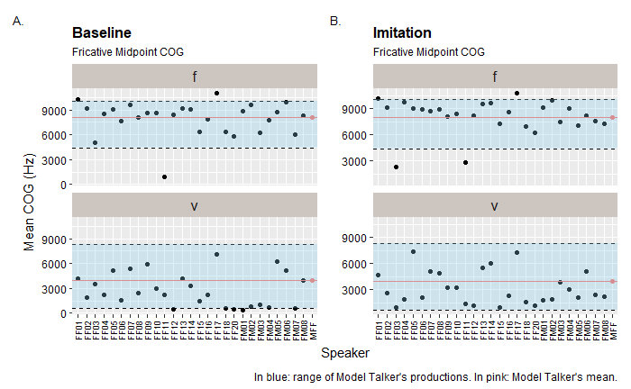

```r
wrap_plots(p.base.f.cog, p.imit.f.cog) +
  plot_layout(axis_titles = "collect", axes = "collect_y") +
  plot_annotation(caption = "In blue: range of Model Talker's productions. In pink: Model Talker's mean.",
                  tag_levels = "A",
                  tag_suffix = ".") &
  theme(plot.tag = element_text(size = 10))
```

Variance

```r
# Baseline
dfFrBase_fric %>%
  ggplot(aes(x = Speaker, y = mean_sd)) +
  theme_gray() +
  geom_point(stat = "identity") +
  geom_point(aes(colour = "pink"), data = dfKlem_fric, stat = "identity", show.legend = FALSE) +
  labs(title = "Baseline",
       subtitle = "Fricative Variance",
       #caption = "In blue: range of Model Talker's productions.",
       y = "Mean Variance (Hz)") +
  geom_hline(data = dfKlem_fric, aes(yintercept = max_sd), linetype = "dashed") +
  geom_hline(data = dfKlem_fric, aes(yintercept = min_sd), linetype = "dashed") +
  geom_hline(data = dfKlem_fric, aes(yintercept = mean_sd, colour = "pink"), show.legend = FALSE) +
  geom_rect(data = dfKlem_fric,
            aes(xmin = -Inf, xmax = Inf, ymin = min_sd, ymax = max_sd),
            fill = "skyblue", alpha = 0.3) +
  theme(plot.title = element_text(face = "bold", size = 12),
        plot.subtitle = element_text(size = 9),
        axis.title.x = element_text(vjust = 0.5),
        axis.title.y = element_text(vjust = 2),
        axis.text.x = element_text(size = 6, angle = 90, vjust = 0.5),
        axis.text = element_text(colour = "black"),
        strip.background = element_rect(fill = "seashell3"),
        strip.text = element_text(size = 12, vjust = 1),
        #plot.margin = margin(r = 0.5, b = 0.25, l = 0.5, unit = "cm")
        ) +
  facet_wrap(~Consonant, ncol = 1) + #coord_fixed(ratio = 1/500)
  coord_cartesian() -> p.base.f.var

# Imitation
dfFrImit_fric %>%
  ggplot(aes(x = Speaker, y = mean_sd)) +
  theme_gray() +
  geom_point(stat = "identity") +
  geom_point(aes(colour = "pink"), data = dfKlem_fric, stat = "identity", show.legend = FALSE) +
  labs(title = "Imitation",
       subtitle = "Fricative Variance",
       #caption = "In blue: range of Model Talker's productions.",
       y = "Mean Variance (Hz)") +
  geom_hline(data = dfKlem_fric, aes(yintercept = max_sd), linetype = "dashed") +
  geom_hline(data = dfKlem_fric, aes(yintercept = min_sd), linetype = "dashed") +
  geom_hline(data = dfKlem_fric, aes(yintercept = mean_sd, colour = "pink"), show.legend = FALSE) +
  geom_rect(data = dfKlem_fric,
            aes(xmin = -Inf, xmax = Inf, ymin = min_sd, ymax = max_sd),
            fill = "skyblue", alpha = 0.3) +
  theme(plot.title = element_text(face = "bold", size = 12),
        plot.subtitle = element_text(size = 9),
        axis.title.x = element_text(vjust = 0.5),
        axis.title.y = element_text(vjust = 2),
        axis.text.x = element_text(size = 6, angle = 90, vjust = 0.5),
        axis.text = element_text(colour = "black"),
        strip.background = element_rect(fill = "seashell3"),
        strip.text = element_text(size = 12, vjust = 1),
        #plot.margin = margin(r = 0.5, b = 0.25, l = 0.5, unit = "cm")
        ) +
  facet_wrap(~Consonant, ncol = 1) + #coord_fixed(ratio = 1/500)
  coord_cartesian() -> p.imit.f.var
```

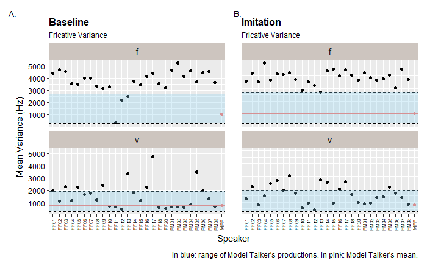

```r
wrap_plots(p.base.f.var, p.imit.f.var) +
  plot_layout(axis_titles = "collect", axes = "collect_y") +
  plot_annotation(caption = "In blue: range of Model Talker's productions. In pink: Model Talker's mean.",
                  tag_levels = "A",
                  tag_suffix = ".") &
  theme(plot.tag = element_text(size = 10))
```

Skewness

```r
# Baseline
dfFrBase_fric %>%
  ggplot(aes(x = Speaker, y = mean_skew)) +
  theme_gray() +
  geom_point(stat = "identity") +
  geom_point(aes(colour = "pink"), data = dfKlem_fric, stat = "identity", show.legend = FALSE) +
  labs(title = "Baseline",
       subtitle = "Fricative Skewness",
       #caption = "In blue: range of Model Talker's productions.",
       y = "Mean Skewness") +
  geom_hline(data = dfKlem_fric, aes(yintercept = max_skew), linetype = "dashed") +
  geom_hline(data = dfKlem_fric, aes(yintercept = min_skew), linetype = "dashed") +
  geom_hline(data = dfKlem_fric, aes(yintercept = mean_skew, colour = "pink"), show.legend = FALSE) +
  geom_rect(data = dfKlem_fric,
            aes(xmin = -Inf, xmax = Inf, ymin = min_skew, ymax = max_skew),
            fill = "skyblue", alpha = 0.3) +
  theme(plot.title = element_text(face = "bold", size = 12),
        plot.subtitle = element_text(size = 9),
        axis.title.x = element_text(vjust = 0.5),
        axis.title.y = element_text(vjust = 2),
        axis.text.x = element_text(size = 6, angle = 90, vjust = 0.5),
        axis.text = element_text(colour = "black"),
        strip.background = element_rect(fill = "seashell3"),
        strip.text = element_text(size = 12, vjust = 1),
        #plot.margin = margin(r = 0.5, b = 0.25, l = 0.5, unit = "cm")
        ) +
  facet_wrap(~Consonant, ncol = 1) + #coord_fixed(ratio = 1/5)
  coord_cartesian() -> p.base.f.skew

# Imitation
dfFrImit_fric %>%
  ggplot(aes(x = Speaker, y = mean_skew)) +
  theme_gray() +
  geom_point(stat = "identity") +
  geom_point(aes(colour = "pink"), data = dfKlem_fric, stat = "identity", show.legend = FALSE) +
  labs(title = "Imitation",
       subtitle = "Fricative Skewness",
       #caption = "In blue: range of Model Talker's productions.",
       y = "Mean Skewness") +
  geom_hline(data = dfKlem_fric, aes(yintercept = max_skew), linetype = "dashed") +
  geom_hline(data = dfKlem_fric, aes(yintercept = min_skew), linetype = "dashed") +
  geom_hline(data = dfKlem_fric, aes(yintercept = mean_skew, colour = "pink"), show.legend = FALSE) +
  geom_rect(data = dfKlem_fric,
            aes(xmin = -Inf, xmax = Inf, ymin = min_skew, ymax = max_skew),
            fill = "skyblue", alpha = 0.3) +
  theme(plot.title = element_text(face = "bold", size = 12),
        plot.subtitle = element_text(size = 9),
        axis.title.x = element_text(vjust = 0.5),
        axis.title.y = element_text(vjust = 2),
        axis.text.x = element_text(size = 6, angle = 90, vjust = 0.5),
        axis.text = element_text(colour = "black"),
        strip.background = element_rect(fill = "seashell3"),
        strip.text = element_text(size = 12, vjust = 1),
        #plot.margin = margin(r = 0.5, b = 0.25, l = 0.5, unit = "cm")
        ) +
  facet_wrap(~Consonant, ncol = 1) + #coord_fixed(ratio = 1/5)
  coord_cartesian() -> p.imit.f.skew
```

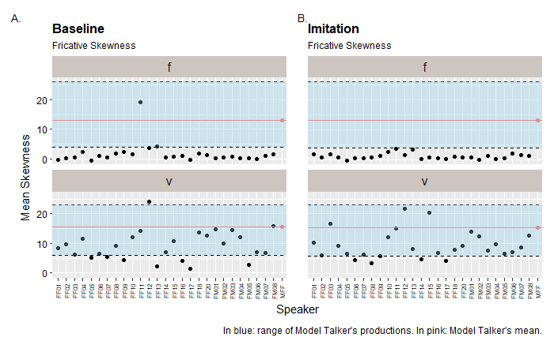

```r
wrap_plots(p.base.f.skew, p.imit.f.skew) +
  plot_layout(axis_titles = "collect", axes = "collect_y") +
  plot_annotation(caption = "In blue: range of Model Talker's productions. In pink: Model Talker's mean.",
                  tag_levels = "A",
                  tag_suffix = ".") &
  theme(plot.tag = element_text(size = 10))
```

Kurtosis

```r
# Baseline
dfFrBase_fric %>%
  ggplot(aes(x = Speaker, y = mean_kurt)) +
  theme_gray() +
  geom_point(stat = "identity") +
  geom_point(aes(colour = "pink"), data = dfKlem_fric, stat = "identity", show.legend = FALSE) +
  labs(title = "Baseline",
       subtitle = "Fricative Kurtosis",
       #caption = "In blue: range of Model Talker's productions.",
       y = "Mean Kurtosis") +
  geom_hline(data = dfKlem_fric, aes(yintercept = max_kurt), linetype = "dashed") +
  geom_hline(data = dfKlem_fric, aes(yintercept = min_kurt), linetype = "dashed") +
  geom_hline(data = dfKlem_fric, aes(yintercept = mean_kurt, colour = "pink"), show.legend = FALSE) +
  geom_rect(data = dfKlem_fric,
            aes(xmin = -Inf, xmax = Inf, ymin = min_kurt, ymax = max_kurt),
            fill = "skyblue", alpha = 0.3) +
  theme(plot.title = element_text(face = "bold", size = 12),
        plot.subtitle = element_text(size = 9),
        axis.title.x = element_text(vjust = 0.5),
        axis.title.y = element_text(vjust = 2),
        axis.text.x = element_text(size = 6, angle = 90, vjust = 0.5),
        axis.text = element_text(colour = "black"),
        strip.background = element_rect(fill = "seashell3"),
        strip.text = element_text(size = 12, vjust = 1),
        #plot.margin = margin(r = 0.5, b = 0.25, l = 0.5, unit = "cm")
        ) +
  facet_wrap(~Consonant, ncol = 1) + #coord_fixed(ratio = 1/50)
  coord_cartesian() -> p.base.f.kurt

# Imitation
dfFrImit_fric %>%
  ggplot(aes(x = Speaker, y = mean_kurt)) +
  theme_gray() +
  geom_point(stat = "identity") +
  geom_point(aes(colour = "pink"), data = dfKlem_fric, stat = "identity", show.legend = FALSE) +
  labs(title = "Imitation",
       subtitle = "Fricative Kurtosis",
       #caption = "In blue: range of Model Talker's productions.",
       y = "Mean Kurtosis") +
  geom_hline(data = dfKlem_fric, aes(yintercept = max_kurt), linetype = "dashed") +
  geom_hline(data = dfKlem_fric, aes(yintercept = min_kurt), linetype = "dashed") +
  geom_hline(data = dfKlem_fric, aes(yintercept = mean_kurt, colour = "pink"), show.legend = FALSE) +
  geom_rect(data = dfKlem_fric,
            aes(xmin = -Inf, xmax = Inf, ymin = min_kurt, ymax = max_kurt),
            fill = "skyblue", alpha = 0.3) +
  theme(plot.title = element_text(face = "bold", size = 12),
        plot.subtitle = element_text(size = 9),
        axis.title.x = element_text(vjust = 0.5),
        axis.title.y = element_text(vjust = 2),
        axis.text.x = element_text(size = 6, angle = 90, vjust = 0.5),
        axis.text = element_text(colour = "black"),
        strip.background = element_rect(fill = "seashell3"),
        strip.text = element_text(size = 12, vjust = 1),
        #plot.margin = margin(r = 0.5, b = 0.25, l = 0.5, unit = "cm")
        ) +
  facet_wrap(~Consonant, ncol = 1) + #coord_fixed(ratio = 1/50)
  coord_cartesian() -> p.imit.f.kurt
```

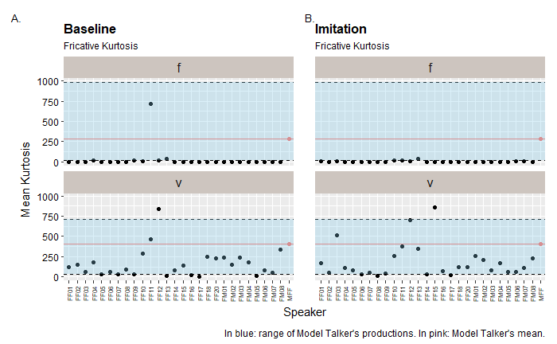

```r
wrap_plots(p.base.f.kurt, p.imit.f.kurt) +
  plot_layout(axis_titles = "collect", axes = "collect_y") +
  plot_annotation(caption = "In blue: range of Model Talker's productions. In pink: Model Talker's mean.",
                  tag_levels = "A",
                  tag_suffix = ".") &
  theme(plot.tag = element_text(size = 10))
```

### 5.1.2 Duration

```r
# Baseline
dfFrBase_fric %>%
  ggplot(aes(x = Speaker, y = mean_dur)) +
  theme_gray() +
  geom_point(stat = "identity", size = 1.2) +
  geom_point(aes(colour = "pink"), size = 1.2, data = dfKlem_fric, stat = "identity", show.legend = FALSE) +
  labs(title = "Baseline",
       subtitle = "Fricative Duration",
       #caption = "In blue: range of Model Talker's productions.",
       y = "Mean Duration (ms)") +
  geom_hline(data = dfKlem_fric, aes(yintercept = max_dur), linetype = "dashed") +
  geom_hline(data = dfKlem_fric, aes(yintercept = min_dur), linetype = "dashed") +
  geom_hline(data = dfKlem_fric, aes(yintercept = mean_dur, colour = "pink"), show.legend = FALSE) +
  geom_rect(data = dfKlem_fric,
            aes(xmin = -Inf, xmax = Inf, ymin = min_dur, ymax = max_dur),
            fill = "skyblue", alpha = 0.3) +
  theme(plot.title = element_text(face = "bold", size = 12),
        plot.subtitle = element_text(size = 9),
        axis.title.x = element_text(vjust = 0.5),
        axis.title.y = element_text(vjust = 2),
        axis.text.x = element_text(size = 6, angle = 90, vjust = 0.5),
        axis.text = element_text(colour = "black"),
        strip.background = element_rect(fill = "seashell3"),
        strip.text = element_text(size = 12, vjust = 1),
        #plot.margin = margin(r = 0.5, b = 0.25, l = 0.5, unit = "cm")
        ) +
  facet_wrap(~Consonant, ncol = 1) + #coord_fixed(ratio = 1/10)
  coord_cartesian(ylim = c(0,310)) -> p.base.f.dur

# Imitation
dfFrImit_fric %>%
  ggplot(aes(x = Speaker, y = mean_dur)) +
  theme_gray() +
  geom_point(stat = "identity", size = 1.2) +
  geom_point(aes(colour = "pink"), size = 1.2, data = dfKlem_fric, stat = "identity", show.legend = FALSE) +
  labs(title = "Imitation",
       subtitle = "Fricative Duration",
       #caption = "In blue: range of Model Talker's productions.",
       y = "Mean Duration (ms)") +
  geom_hline(data = dfKlem_fric, aes(yintercept = max_dur), linetype = "dashed") +
  geom_hline(data = dfKlem_fric, aes(yintercept = min_dur), linetype = "dashed") +
  geom_hline(data = dfKlem_fric, aes(yintercept = mean_dur, colour = "pink"), show.legend = FALSE) +
  geom_rect(data = dfKlem_fric,
            aes(xmin = -Inf, xmax = Inf, ymin = min_dur, ymax = max_dur),
            fill = "skyblue", alpha = 0.3) +
  theme(plot.title = element_text(face = "bold", size = 12),
        plot.subtitle = element_text(size = 9),
        axis.title.x = element_text(vjust = 0.5),
        axis.title.y = element_text(vjust = 2),
        axis.text.x = element_text(size = 6, angle = 90, vjust = 0.5),
        axis.text = element_text(colour = "black"),
        strip.background = element_rect(fill = "seashell3"),
        strip.text = element_text(size = 12, vjust = 1),
        #plot.margin = margin(r = 0.5, b = 0.25, l = 0.5, unit = "cm")
        ) +
  facet_wrap(~Consonant, ncol = 1) + #coord_fixed(ratio = 1/10)
  coord_cartesian(ylim = c(0,310)) -> p.imit.f.dur
```

```r
p.fdur.side <- wrap_plots(p.base.f.dur, p.imit.f.dur) +
  plot_layout(axis_titles = "collect", axes = "collect_y") +
  plot_annotation(caption = "In blue: range of Model Talker's productions. In pink: Model Talker's mean.",
                  tag_levels = "A",
                  tag_suffix = ".") &
  theme(plot.tag = element_text(size = 10))
```

|  | t | l | b | r |
| --- | --- | --- | --- | --- |
| 1: | 1 | 1 | 1 | 1 |
| 2: | 1 | 2 | 1 | 2 |

```r
ggsave("fr_side_fdur.png", p.fdur.side, device = agg_png, width = 12,
       height = 8, units = "cm", res = 300, scaling = 0.7)
```

## 5.2 Stops

### 5.2.1 Spectral Moments

COG

```r
# Baseline
dfFrBase_stop %>%
  ggplot(aes(x = Speaker, y = mean_cog)) +
  theme_gray() +
  geom_point(stat = "identity") +
  geom_point(aes(colour = "pink"), data = dfKlem_stop, stat = "identity", show.legend = FALSE) +
  labs(title = "Baseline",
       subtitle = "Stop Burst COG",
       #caption = "In blue: range of Model Talker's productions.",
       y = "Mean COG (Hz)") +
  geom_hline(data = dfKlem_stop, aes(yintercept = max_cog), linetype = "dashed") +
  geom_hline(data = dfKlem_stop, aes(yintercept = min_cog), linetype = "dashed") +
  geom_hline(data = dfKlem_stop, aes(yintercept = mean_cog, colour = "pink"), show.legend = FALSE) +
  geom_rect(data = dfKlem_stop,
            aes(xmin = -Inf, xmax = Inf, ymin = min_cog, ymax = max_cog),
            fill = "skyblue", alpha = 0.3) +
  theme(plot.title = element_text(face = "bold", size = 12),
        plot.subtitle = element_text(size = 9),
        axis.title.x = element_text(vjust = 0.5),
        axis.title.y = element_text(vjust = 2),
        axis.text.x = element_text(size = 6, angle = 90, vjust = 0.5),
        axis.text = element_text(colour = "black"),
        strip.background = element_rect(fill = "seashell3"),
        strip.text = element_text(size = 12, vjust = 1),
        #plot.margin = margin(r = 0.5, b = 0.25, l = 0.5, unit = "cm")
        ) +
  facet_wrap(~Consonant, ncol = 1) +
  coord_cartesian() -> p.base.s.cog
  #coord_fixed(ratio = 1/500)

# Imitation
dfFrImit_stop %>%
  ggplot(aes(x = Speaker, y = mean_cog)) +
  theme_gray() +
  geom_point(stat = "identity") +
  geom_point(aes(colour = "pink"), data = dfKlem_stop, stat = "identity", show.legend = FALSE) +
  labs(title = "Imitation",
       subtitle = "Stop Burst COG",
       #caption = "In blue: range of Model Talker's productions.",
       y = "Mean COG (Hz)") +
  geom_hline(data = dfKlem_stop, aes(yintercept = max_cog), linetype = "dashed") +
  geom_hline(data = dfKlem_stop, aes(yintercept = min_cog), linetype = "dashed") +
  geom_hline(data = dfKlem_stop, aes(yintercept = mean_cog, colour = "pink"), show.legend = FALSE) +
  geom_rect(data = dfKlem_stop,
            aes(xmin = -Inf, xmax = Inf, ymin = min_cog, ymax = max_cog),
            fill = "skyblue", alpha = 0.3) +
  theme(plot.title = element_text(face = "bold", size = 12),
        plot.subtitle = element_text(size = 9),
        axis.title.x = element_text(vjust = 0.5),
        axis.title.y = element_text(vjust = 2),
        axis.text.x = element_text(size = 6, angle = 90, vjust = 0.5),
        axis.text = element_text(colour = "black"),
        strip.background = element_rect(fill = "seashell3"),
        strip.text = element_text(size = 12, vjust = 1),
        #plot.margin = margin(r = 0.5, b = 0.25, l = 0.5, unit = "cm")
        ) +
  facet_wrap(~Consonant, ncol = 1) +
  coord_cartesian() -> p.imit.s.cog
  #coord_fixed(ratio = 1/500)
```

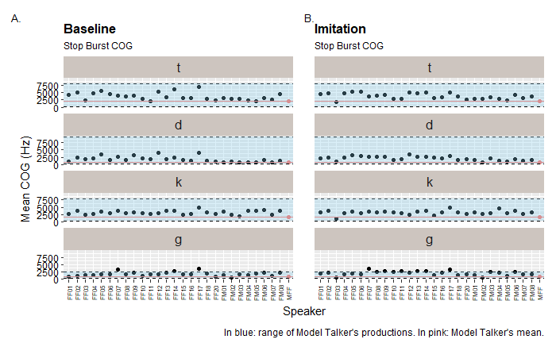

```r
wrap_plots(p.base.s.cog, p.imit.s.cog) +
  plot_layout(axis_titles = "collect", axes = "collect_y") +
  plot_annotation(caption = "In blue: range of Model Talker's productions. In pink: Model Talker's mean.",
                  tag_levels = "A",
                  tag_suffix = ".") &
  theme(plot.tag = element_text(size = 10))
```

Variance

```r
# Baseline
dfFrBase_stop %>%
  ggplot(aes(x = Speaker, y = mean_sd)) +
  theme_gray() +
  geom_point(stat = "identity") +
  geom_point(aes(colour = "pink"), data = dfKlem_stop, stat = "identity", show.legend = FALSE) +
  labs(title = "Baseline",
       subtitle = "Stop Burst Variance",
       #caption = "In blue: range of Model Talker's productions.",
       y = "Mean Variance (Hz)") +
  geom_hline(data = dfKlem_stop, aes(yintercept = max_sd), linetype = "dashed") +
  geom_hline(data = dfKlem_stop, aes(yintercept = min_sd), linetype = "dashed") +
  geom_hline(data = dfKlem_stop, aes(yintercept = mean_sd, colour = "pink"), show.legend = FALSE) +
  geom_rect(data = dfKlem_stop,
            aes(xmin = -Inf, xmax = Inf, ymin = min_sd, ymax = max_sd),
            fill = "skyblue", alpha = 0.3) +
  theme(plot.title = element_text(face = "bold", size = 12),
        plot.subtitle = element_text(size = 9),
        axis.title.x = element_text(vjust = 0.5),
        axis.title.y = element_text(vjust = 2),
        axis.text.x = element_text(size = 6, angle = 90, vjust = 0.5),
        axis.text = element_text(colour = "black"),
        strip.background = element_rect(fill = "seashell3"),
        strip.text = element_text(size = 12, vjust = 1),
        #plot.margin = margin(r = 0.5, b = 0.25, l = 0.5, unit = "cm")
        ) +
  facet_wrap(~Consonant, ncol = 1) +
  coord_cartesian() -> p.base.s.var
  #coord_fixed(ratio = 1/500)

# Imitation
dfFrImit_stop %>%
  ggplot(aes(x = Speaker, y = mean_sd)) +
  theme_gray() +
  geom_point(stat = "identity") +
  geom_point(aes(colour = "pink"), data = dfKlem_stop, stat = "identity", show.legend = FALSE) +
  labs(title = "Imitation",
       subtitle = "Stop Burst Variance",
       #caption = "In blue: range of Model Talker's productions.",
       y = "Mean Variance (Hz)") +
  geom_hline(data = dfKlem_stop, aes(yintercept = max_sd), linetype = "dashed") +
  geom_hline(data = dfKlem_stop, aes(yintercept = min_sd), linetype = "dashed") +
  geom_hline(data = dfKlem_stop, aes(yintercept = mean_sd, colour = "pink"), show.legend = FALSE) +
  geom_rect(data = dfKlem_stop,
            aes(xmin = -Inf, xmax = Inf, ymin = min_sd, ymax = max_sd),
            fill = "skyblue", alpha = 0.3) +
  theme(plot.title = element_text(face = "bold", size = 12),
        plot.subtitle = element_text(size = 9),
        axis.title.x = element_text(vjust = 0.5),
        axis.title.y = element_text(vjust = 2),
        axis.text.x = element_text(size = 6, angle = 90, vjust = 0.5),
        axis.text = element_text(colour = "black"),
        strip.background = element_rect(fill = "seashell3"),
        strip.text = element_text(size = 12, vjust = 1),
        #plot.margin = margin(r = 0.5, b = 0.25, l = 0.5, unit = "cm")
        ) +
  facet_wrap(~Consonant, ncol = 1) +
  coord_cartesian() -> p.imit.s.var
  #coord_fixed(ratio = 1/500)
```

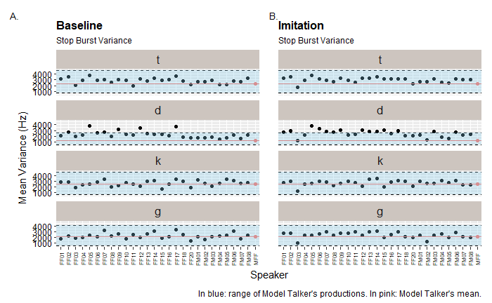

```r
wrap_plots(p.base.s.var, p.imit.s.var) +
  plot_layout(axis_titles = "collect", axes = "collect_y") +
  plot_annotation(caption = "In blue: range of Model Talker's productions. In pink: Model Talker's mean.",
                  tag_levels = "A",
                  tag_suffix = ".") &
  theme(plot.tag = element_text(size = 10))
```

Skewness

```r
# Baseline
dfFrBase_stop %>%
  ggplot(aes(x = Speaker, y = mean_skew)) +
  theme_gray() +
  geom_point(stat = "identity") +
  geom_point(aes(colour = "pink"), data = dfKlem_stop, stat = "identity", show.legend = FALSE) +
  labs(title = "Baseline",
       subtitle = "Stop Burst Skewness",
       #caption = "In blue: range of Model Talker's productions.",
       y = "Mean Skewness") +
  geom_hline(data = dfKlem_stop, aes(yintercept = max_skew), linetype = "dashed") +
  geom_hline(data = dfKlem_stop, aes(yintercept = min_skew), linetype = "dashed") +
  geom_hline(data = dfKlem_stop, aes(yintercept = mean_skew, colour = "pink"), show.legend = FALSE) +
  geom_rect(data = dfKlem_stop,
            aes(xmin = -Inf, xmax = Inf, ymin = min_skew, ymax = max_skew),
            fill = "skyblue", alpha = 0.3) +
  theme(plot.title = element_text(face = "bold", size = 12),
        plot.subtitle = element_text(size = 9),
        axis.title.x = element_text(vjust = 0.5),
        axis.title.y = element_text(vjust = 2),
        axis.text.x = element_text(size = 6, angle = 90, vjust = 0.5),
        axis.text = element_text(colour = "black"),
        strip.background = element_rect(fill = "seashell3"),
        strip.text = element_text(size = 12, vjust = 1),
        #plot.margin = margin(r = 0.5, b = 0.25, l = 0.5, unit = "cm")
        ) +
  facet_wrap(~Consonant, ncol = 1) +
  coord_cartesian() -> p.base.s.skew
  #coord_fixed(ratio = 1/2)

# Imitation
dfFrImit_stop %>%
  ggplot(aes(x = Speaker, y = mean_skew)) +
  theme_gray() +
  geom_point(stat = "identity") +
  geom_point(aes(colour = "pink"), data = dfKlem_stop, stat = "identity", show.legend = FALSE) +
  labs(title = "Imitation",
       subtitle = "Stop Burst Skewness",
       #caption = "In blue: range of Model Talker's productions.",
       y = "Mean Skewness") +
  geom_hline(data = dfKlem_stop, aes(yintercept = max_skew), linetype = "dashed") +
  geom_hline(data = dfKlem_stop, aes(yintercept = min_skew), linetype = "dashed") +
  geom_hline(data = dfKlem_stop, aes(yintercept = mean_skew, colour = "pink"), show.legend = FALSE) +
  geom_rect(data = dfKlem_stop,
            aes(xmin = -Inf, xmax = Inf, ymin = min_skew, ymax = max_skew),
            fill = "skyblue", alpha = 0.3) +
  theme(plot.title = element_text(face = "bold", size = 12),
        plot.subtitle = element_text(size = 9),
        axis.title.x = element_text(vjust = 0.5),
        axis.title.y = element_text(vjust = 2),
        axis.text.x = element_text(size = 6, angle = 90, vjust = 0.5),
        axis.text = element_text(colour = "black"),
        strip.background = element_rect(fill = "seashell3"),
        strip.text = element_text(size = 12, vjust = 1),
        #plot.margin = margin(r = 0.5, b = 0.25, l = 0.5, unit = "cm")
        ) +
  facet_wrap(~Consonant, ncol = 1) +
  coord_cartesian() -> p.imit.s.skew
  #coord_fixed(ratio = 1/2)
```

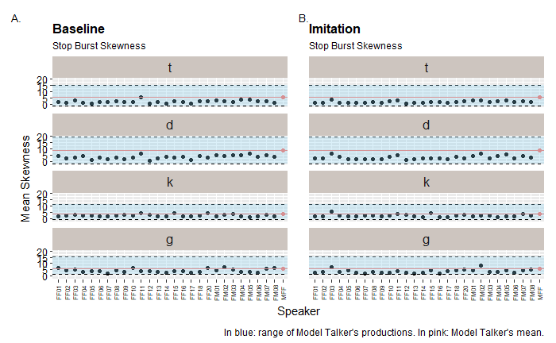

```r
wrap_plots(p.base.s.skew, p.imit.s.skew) +
  plot_layout(axis_titles = "collect", axes = "collect_y") +
  plot_annotation(caption = "In blue: range of Model Talker's productions. In pink: Model Talker's mean.",
                  tag_levels = "A",
                  tag_suffix = ".") &
  theme(plot.tag = element_text(size = 10))
```

Kurtosis

```r
# Baseline
dfFrBase_stop %>%
  ggplot(aes(x = Speaker, y = mean_kurt)) +
  theme_gray() +
  geom_point(stat = "identity") +
  geom_point(aes(colour = "pink"), data = dfKlem_stop, stat = "identity", show.legend = FALSE) +
  labs(title = "Baseline",
       subtitle = "Stop Burst Kurtosis",
       #caption = "In blue: range of Model Talker's productions.",
       y = "Mean Kurtosis") +
  geom_hline(data = dfKlem_stop, aes(yintercept = max_kurt), linetype = "dashed") +
  geom_hline(data = dfKlem_stop, aes(yintercept = min_kurt), linetype = "dashed") +
  geom_hline(data = dfKlem_stop, aes(yintercept = mean_kurt, colour = "pink"), show.legend = FALSE) +
  geom_rect(data = dfKlem_stop,
            aes(xmin = -Inf, xmax = Inf, ymin = min_kurt, ymax = max_kurt),
            fill = "skyblue", alpha = 0.3) +
  theme(plot.title = element_text(face = "bold", size = 12),
        plot.subtitle = element_text(size = 9),
        axis.title.x = element_text(vjust = 0.5),
        axis.title.y = element_text(vjust = 2),
        axis.text.x = element_text(size = 6, angle = 90, vjust = 0.5),
        axis.text = element_text(colour = "black"),
        strip.background = element_rect(fill = "seashell3"),
        strip.text = element_text(size = 12, vjust = 1),
        #plot.margin = margin(r = 0.5, b = 0.25, l = 0.5, unit = "cm")
        ) +
  facet_wrap(~Consonant, ncol = 1) +
  coord_cartesian() -> p.base.s.kurt
  #coord_fixed(ratio = 1/50)

# Imitation
dfFrImit_stop %>%
  ggplot(aes(x = Speaker, y = mean_kurt)) +
  theme_gray() +
  geom_point(stat = "identity") +
  geom_point(aes(colour = "pink"), data = dfKlem_stop, stat = "identity", show.legend = FALSE) +
  labs(title = "Imitation",
       subtitle = "Stop Burst Kurtosis",
       #caption = "In blue: range of Model Talker's productions.",
       y = "Mean Kurtosis") +
  geom_hline(data = dfKlem_stop, aes(yintercept = max_kurt), linetype = "dashed") +
  geom_hline(data = dfKlem_stop, aes(yintercept = min_kurt), linetype = "dashed") +
  geom_hline(data = dfKlem_stop, aes(yintercept = mean_kurt, colour = "pink"), show.legend = FALSE) +
  geom_rect(data = dfKlem_stop,
            aes(xmin = -Inf, xmax = Inf, ymin = min_kurt, ymax = max_kurt),
            fill = "skyblue", alpha = 0.3) +
  theme(plot.title = element_text(face = "bold", size = 12),
        plot.subtitle = element_text(size = 9),
        axis.title.x = element_text(vjust = 0.5),
        axis.title.y = element_text(vjust = 2),
        axis.text.x = element_text(size = 6, angle = 90, vjust = 0.5),
        axis.text = element_text(colour = "black"),
        strip.background = element_rect(fill = "seashell3"),
        strip.text = element_text(size = 12, vjust = 1),
        #plot.margin = margin(r = 0.5, b = 0.25, l = 0.5, unit = "cm")
        ) +
  facet_wrap(~Consonant, ncol = 1) +
  coord_cartesian() -> p.imit.s.kurt
  #coord_fixed(ratio = 1/50)
```

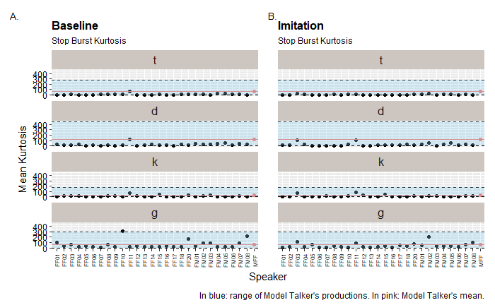

```r
wrap_plots(p.base.s.kurt, p.imit.s.kurt) +
  plot_layout(axis_titles = "collect", axes = "collect_y") +
  plot_annotation(caption = "In blue: range of Model Talker's productions. In pink: Model Talker's mean.",
                  tag_levels = "A",
                  tag_suffix = ".") &
  theme(plot.tag = element_text(size = 10))
```

### 5.2.2 Duration

```r
# Baseline
dfFrBase_stop %>%
  ggplot(aes(x = Speaker, y = mean_dur)) +
  theme_gray() +
  geom_point(stat = "identity") +
  geom_point(aes(colour = "pink"), data = dfKlem_stop, stat = "identity", show.legend = FALSE) +
  labs(title = "Baseline",
       subtitle = "Stop Burst Duration",
       #caption = "In blue: range of Model Talker's productions.",
       y = "Mean Duration (ms)") +
  geom_hline(data = dfKlem_stop, aes(yintercept = max_dur), linetype = "dashed") +
  geom_hline(data = dfKlem_stop, aes(yintercept = min_dur), linetype = "dashed") +
  geom_hline(data = dfKlem_stop, aes(yintercept = mean_dur, colour = "pink"), show.legend = FALSE) +
  geom_rect(data = dfKlem_stop,
            aes(xmin = -Inf, xmax = Inf, ymin = min_dur, ymax = max_dur),
            fill = "skyblue", alpha = 0.3) +
  theme(plot.title = element_text(face = "bold", size = 12),
        plot.subtitle = element_text(size = 9),
        axis.title.x = element_text(vjust = 0.5),
        axis.title.y = element_text(vjust = 2),
        axis.text.x = element_text(size = 6, angle = 90, vjust = 0.5),
        axis.text = element_text(colour = "black"),
        strip.background = element_rect(fill = "seashell3"),
        strip.text = element_text(size = 12, vjust = 1),
        #plot.margin = margin(r = 0.5, b = 0.25, l = 0.5, unit = "cm")
        ) +
  facet_wrap(~Consonant, ncol = 1) +
  coord_cartesian() -> p.base.s.dur
  #coord_fixed(ratio = 1/10)

# Imitation
dfFrImit_stop %>%
  ggplot(aes(x = Speaker, y = mean_dur)) +
  theme_gray() +
  geom_point(stat = "identity") +
  geom_point(aes(colour = "pink"), data = dfKlem_stop, stat = "identity", show.legend = FALSE) +
  labs(title = "Imitation",
       subtitle = "Stop Burst Duration",
       #caption = "In blue: range of Model Talker's productions.",
       y = "Mean Duration (ms)") +
  geom_hline(data = dfKlem_stop, aes(yintercept = max_dur), linetype = "dashed") +
  geom_hline(data = dfKlem_stop, aes(yintercept = min_dur), linetype = "dashed") +
  geom_hline(data = dfKlem_stop, aes(yintercept = mean_dur, colour = "pink"), show.legend = FALSE) +
  geom_rect(data = dfKlem_stop,
            aes(xmin = -Inf, xmax = Inf, ymin = min_dur, ymax = max_dur),
            fill = "skyblue", alpha = 0.3) +
  theme(plot.title = element_text(face = "bold", size = 12),
        plot.subtitle = element_text(size = 9),
        axis.title.x = element_text(vjust = 0.5),
        axis.title.y = element_text(vjust = 2),
        axis.text.x = element_text(size = 6, angle = 90, vjust = 0.5),
        axis.text = element_text(colour = "black"),
        strip.background = element_rect(fill = "seashell3"),
        strip.text = element_text(size = 12, vjust = 1),
        #plot.margin = margin(r = 0.5, b = 0.25, l = 0.5, unit = "cm")
        ) +
  facet_wrap(~Consonant, ncol = 1) +
  coord_cartesian() -> p.imit.s.dur
  #coord_fixed(ratio = 1/10)
```

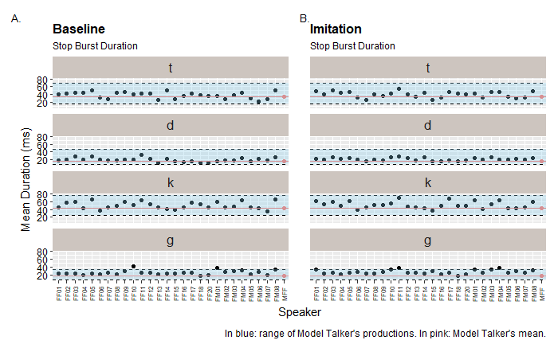

```r
wrap_plots(p.base.s.dur, p.imit.s.dur) +
  plot_layout(axis_titles = "collect", axes = "collect_y") +
  plot_annotation(caption = "In blue: range of Model Talker's productions. In pink: Model Talker's mean.",
                  tag_levels = "A",
                  tag_suffix = ".") &
  theme(plot.tag = element_text(size = 10))
```

### 5.2.3 VOT

```r
# Baseline
dfFrBase_stop %>%
  ggplot(aes(x = Speaker, y = mean_vot)) +
  theme_gray() +
  geom_point(stat = "identity", size = 1.2) +
  geom_point(aes(colour = "pink"), size = 1.2, data = dfKlem_stop, stat = "identity", show.legend = FALSE) +
  labs(title = "Baseline",
       subtitle = "Stop VOT",
       #caption = "In blue: range of Model Talker's productions.",
       y = "Mean VOT (ms)") +
  geom_hline(data = dfKlem_stop, aes(yintercept = max_vot), linetype = "dashed") +
  geom_hline(data = dfKlem_stop, aes(yintercept = min_vot), linetype = "dashed") +
  geom_hline(data = dfKlem_stop, aes(yintercept = mean_vot, colour = "pink"), show.legend = FALSE) +
  geom_rect(data = dfKlem_stop,
            aes(xmin = -Inf, xmax = Inf, ymin = min_vot, ymax = max_vot),
            fill = "skyblue", alpha = 0.3) +
  theme(plot.title = element_text(face = "bold", size = 12),
        plot.subtitle = element_text(size = 9),
        axis.title.x = element_text(vjust = 0.5),
        axis.title.y = element_text(vjust = 2),
        axis.text.x = element_text(size = 6, angle = 90, vjust = 0.5),
        axis.text = element_text(colour = "black"),
        strip.background = element_rect(fill = "seashell3"),
        strip.text = element_text(size = 12, vjust = 1),
        #plot.margin = margin(r = 0.5, b = 0.25, l = 0.5, unit = "cm")
        ) +
  facet_wrap(~Consonant, ncol = 1) +
  coord_cartesian(ylim = c(-200,75)) -> p.base.s.vot
  #coord_fixed(ratio = 1/20)

# Imitation
dfFrImit_stop %>%
  ggplot(aes(x = Speaker, y = mean_vot)) +
  theme_gray() +
  geom_point(stat = "identity", size = 1.2) +
  geom_point(aes(colour = "pink"), size = 1.2, data = dfKlem_stop, stat = "identity", show.legend = FALSE) +
  labs(title = "Imitation",
       subtitle = "Stop VOT",
       #caption = "In blue: range of Model Talker's productions.",
       y = "Mean VOT (ms)") +
  geom_hline(data = dfKlem_stop, aes(yintercept = max_vot), linetype = "dashed") +
  geom_hline(data = dfKlem_stop, aes(yintercept = min_vot), linetype = "dashed") +
  geom_hline(data = dfKlem_stop, aes(yintercept = mean_vot, colour = "pink"), show.legend = FALSE) +
  geom_rect(data = dfKlem_stop,
            aes(xmin = -Inf, xmax = Inf, ymin = min_vot, ymax = max_vot),
            fill = "skyblue", alpha = 0.3) +
  theme(plot.title = element_text(face = "bold", size = 12),
        plot.subtitle = element_text(size = 9),
        axis.title.x = element_text(vjust = 0.5),
        axis.title.y = element_text(vjust = 2),
        axis.text.x = element_text(size = 6, angle = 90, vjust = 0.5),
        axis.text = element_text(colour = "black"),
        strip.background = element_rect(fill = "seashell3"),
        strip.text = element_text(size = 12, vjust = 1),
        #plot.margin = margin(r = 0.5, b = 0.25, l = 0.5, unit = "cm")
        ) +
  facet_wrap(~Consonant, ncol = 1) +
  coord_cartesian(ylim = c(-200,75)) -> p.imit.s.vot
  #coord_fixed(ratio = 1/20)
```

```r
p.vot.all <- wrap_plots(p.base.s.vot, p.imit.s.vot) +
  plot_layout(axis_titles = "collect", axes = "collect_y") +
  plot_annotation(caption = "In blue: range of Model Talker's productions. In pink: Model Talker's mean.",
                  tag_levels = "A",
                  tag_suffix = ".") &
  theme(plot.tag = element_text(size = 10))
```

|  | t | l | b | r |
| --- | --- | --- | --- | --- |
| 1: | 1 | 1 | 1 | 1 |
| 2: | 1 | 2 | 1 | 2 |

```r
ggsave("fr_side_vot.png", p.vot.all, device = agg_png, width = 12,
       height = 10, units = "cm", res = 300, scaling = 0.7)
```

## 5.3 Proximity

Box plots may be the simpler, more concise manner for displaying the range. Once we figure out how to choose who was a high imitator this may change.

One method may be to simply select the top 5, for each measure and each consonant, then see who shows up consistently.

### 5.3.1 Fricatives

Spectral Moments

```r
# COG
dfFr_prox %>%
  filter(Consonant %in% c("f","v")) %>%
  ggplot(aes(x = Consonant, y = prox_cog_mid)) +
  theme_gray() +
  geom_boxplot(width = 0.5) +
  geom_point(aes(colour = "pink", alpha = 0.3), size = 1.2, stat = "identity", show.legend = FALSE) +
  theme(plot.title = element_text(face = "bold", size = 12),
        plot.subtitle = element_text(size = 8),
        axis.title.x = element_text(vjust = 0.5),
        axis.title.y = element_text(vjust = 2),
        axis.text.x = element_text(size = 11),
        axis.text.y = element_text(size = 10),
        axis.text = element_text(colour = "black")) +
  labs(title = "Proximity Mean COG",
       #subtitle = "Closer to zero is better.",
       y = "Proximity (Hz)") +
  coord_cartesian() -> p.fr.f.cog

dfFr_prox %>%
  filter(Consonant %in% c("f","v")) %>%
  ggplot(aes(x = Consonant, y = prox_sd_mid)) +
  theme_gray() +
  geom_boxplot(width = 0.5) +
  geom_point(aes(colour = "pink", alpha = 0.3), size = 1.2, stat = "identity", show.legend = FALSE) +
  theme(plot.title = element_text(face = "bold", size = 12),
        plot.subtitle = element_text(size = 8),
        axis.title.x = element_text(vjust = 0.5),
        axis.title.y = element_text(vjust = 2),
        axis.text.x = element_text(size = 11),
        axis.text.y = element_text(size = 10),
        axis.text = element_text(colour = "black")) +
  labs(title = "Proximity Variance",
       #subtitle = "Closer to zero is better.",
       y = "Proximity (Hz)") +
  coord_cartesian() -> p.fr.f.var

dfFr_prox %>%
  filter(Consonant %in% c("f","v")) %>%
  ggplot(aes(x = Consonant, y = prox_skew_mid)) +
  theme_gray() +
  geom_boxplot(width = 0.5) +
  geom_point(aes(colour = "pink", alpha = 0.3), size = 1.2, stat = "identity", show.legend = FALSE) +
  theme(plot.title = element_text(face = "bold", size = 12),
        plot.subtitle = element_text(size = 8),
        axis.title.x = element_text(vjust = 0.5),
        axis.title.y = element_text(vjust = 2),
        axis.text.x = element_text(size = 11),
        axis.text.y = element_text(size = 10),
        axis.text = element_text(colour = "black")) +
  labs(title = "Proximity Skewness",
       #subtitle = "Closer to zero is better.",
       y = "Proximity") +
  coord_cartesian() -> p.fr.f.skew

dfFr_prox %>%
  filter(Consonant %in% c("f","v")) %>%
  ggplot(aes(x = Consonant, y = prox_kurt_mid)) +
  theme_gray() +
  geom_boxplot(width = 0.5) +
  geom_point(aes(colour = "pink", alpha = 0.3), size = 1.2, stat = "identity", show.legend = FALSE) +
  theme(plot.title = element_text(face = "bold", size = 12),
        plot.subtitle = element_text(size = 8),
        axis.title.x = element_text(vjust = 0.5),
        axis.title.y = element_text(vjust = 2),
        axis.text.x = element_text(size = 11),
        axis.text.y = element_text(size = 10),
        axis.text = element_text(colour = "black")) +
  labs(title = "Proximity Kurtosis",
       #subtitle = "Closer to zero is better.",
       y = "Proximity") +
  coord_cartesian() -> p.fr.f.kurt
```

Making a wrapped plot

```r
p.fr.f.all <- wrap_plots(p.fr.f.cog, p.fr.f.var, p.fr.f.skew, p.fr.f.kurt) +
  plot_layout(axis_titles = "collect", axes = "collect_x") +
  plot_annotation(caption = "Closer to zero is better.",
                  tag_levels = "A",
                  tag_suffix = ".") &
  theme(plot.tag = element_text(size = 10))
```

|  | t | l | b | r |
| --- | --- | --- | --- | --- |
| 1: | 1 | 1 | 1 | 1 |
| 2: | 2 | 1 | 2 | 1 |
| 3: | 1 | 2 | 1 | 2 |
| 4: | 2 | 2 | 2 | 2 |

```r
ggsave("fr_prox_f.png", p.fr.f.all, device = agg_png, width = 12,
       height = 10, units = "cm", res = 300, scaling = 0.7)
```

Duration

```r
# Duration
dfFr_prox %>%
  filter(Consonant %in% c("f","v")) %>%
  ggplot(aes(x = Consonant, y = prox_dur)) +
  theme_gray() +
  geom_boxplot(width = 0.5) +
  geom_point(aes(colour = "pink", alpha = 0.3), size = 1.2, stat = "identity", show.legend = FALSE) +
  theme(plot.title = element_text(face = "bold", size = 12),
        plot.subtitle = element_text(size = 9),
        axis.title.x = element_text(vjust = 0.5),
        axis.title.y = element_text(vjust = 2),
        axis.text.x = element_text(size = 11),
        axis.text.y = element_text(size = 10),
        axis.text = element_text(colour = "black")) +
  labs(title = "Proximity Duration",
       subtitle = "Closer to zero is better.",
       y = "Proximity (ms)") +
  coord_cartesian() -> p.fr.f.dur

ggsave("fr_prox_fdur.png", p.fr.f.dur, device = agg_png, width = 7,
       height = 6, units = "cm", res = 300, scaling = 0.7)
```

### 5.3.2 Stops

Spectral Moments

```r
# COG
dfFr_prox %>%
  filter(!Consonant %in% c("f","v")) %>%
  ggplot(aes(x = Consonant, y = prox_cog)) +
  theme_gray() +
  geom_boxplot(width = 0.5) +
  geom_point(aes(colour = "pink", alpha = 0.3), size = 1.2, stat = "identity", show.legend = FALSE) +
  theme(plot.title = element_text(face = "bold", size = 12),
        plot.subtitle = element_text(size = 8),
        axis.title.x = element_text(vjust = 0.5),
        axis.title.y = element_text(vjust = 2),
        axis.text.x = element_text(size = 11),
        axis.text.y = element_text(size = 10),
        axis.text = element_text(colour = "black")) +
  labs(title = "Proximity Stops: Mean CoG",
       #subtitle = "closer to zero is better.",
       y = "Proximity (Hz)") +
  coord_cartesian() -> p.fr.s.cog

dfFr_prox %>%
  filter(!Consonant %in% c("f","v")) %>%
  ggplot(aes(x = Consonant, y = prox_sd)) +
  theme_gray() +
  geom_boxplot(width = 0.5) +
  geom_point(aes(colour = "pink", alpha = 0.3), size = 1.2, stat = "identity", show.legend = FALSE) +
  theme(plot.title = element_text(face = "bold", size = 12),
        plot.subtitle = element_text(size = 8),
        axis.title.x = element_text(vjust = 0.5),
        axis.title.y = element_text(vjust = 2),
        axis.text.x = element_text(size = 11),
        axis.text.y = element_text(size = 10),
        axis.text = element_text(colour = "black")) +
  labs(title = "Proximity Stops: Variance",
       #subtitle = "closer to zero is better.",
       y = "Proximity (Hz)") +
  coord_cartesian() -> p.fr.s.var

dfFr_prox %>%
  filter(!Consonant %in% c("f","v")) %>%
  ggplot(aes(x = Consonant, y = prox_skew)) +
  theme_gray() +
  geom_boxplot(width = 0.5) +
  geom_point(aes(colour = "pink", alpha = 0.3), size = 1.2, stat = "identity", show.legend = FALSE) +
  theme(plot.title = element_text(face = "bold", size = 12),
        plot.subtitle = element_text(size = 8),
        axis.title.x = element_text(vjust = 0.5),
        axis.title.y = element_text(vjust = 2),
        axis.text.x = element_text(size = 11),
        axis.text.y = element_text(size = 10),
        axis.text = element_text(colour = "black")) +
  labs(title = "Proximity Stops: Skewness",
       #subtitle = "closer to zero is better.",
       y = "Proximity") +
  coord_cartesian() -> p.fr.s.skew

dfFr_prox %>%
  filter(!Consonant %in% c("f","v")) %>%
  ggplot(aes(x = Consonant, y = prox_kurt)) +
  theme_gray() +
  geom_boxplot(width = 0.5) +
  geom_point(aes(colour = "pink", alpha = 0.3), size = 1.2, stat = "identity", show.legend = FALSE) +
  theme(plot.title = element_text(face = "bold", size = 12),
        plot.subtitle = element_text(size = 8),
        axis.title.x = element_text(vjust = 0.5),
        axis.title.y = element_text(vjust = 2),
        axis.text.x = element_text(size = 11),
        axis.text.y = element_text(size = 10),
        axis.text = element_text(colour = "black")) +
  labs(title = "Proximity Stops: Kurtosis",
       #subtitle = "closer to zero is better.",
       y = "Proximity") +
  coord_cartesian() -> p.fr.s.kurt
```

Making a wrapped plot

```r
p.fr.s.all <- wrap_plots(p.fr.s.cog, p.fr.s.var, p.fr.s.skew, p.fr.s.kurt) +
  plot_layout(axis_titles = "collect", axes = "collect_x") +
  plot_annotation(caption = "Closer to zero is better.",
                  tag_levels = "A",
                  tag_suffix = ".") &
  theme(plot.tag = element_text(size = 10))
```

|  | t | l | b | r |
| --- | --- | --- | --- | --- |
| 1: | 1 | 1 | 1 | 1 |
| 2: | 2 | 1 | 2 | 1 |
| 3: | 1 | 2 | 1 | 2 |
| 4: | 2 | 2 | 2 | 2 |

```r
ggsave("fr_prox_s.png", p.fr.s.all, device = agg_png, width = 12,
       height = 10, units = "cm", res = 300, scaling = 0.7)
```

Duration

```r
# Duration
dfFr_prox %>%
  filter(!Consonant %in% c("f","v")) %>%
  ggplot(aes(x = Consonant, y = prox_dur)) +
  theme_gray() +
  geom_boxplot(width = 0.5) +
  geom_point(aes(colour = "pink", alpha = 0.3), size = 1.2, stat = "identity", show.legend = FALSE) +
  theme(plot.title = element_text(face = "bold", size = 12),
        plot.subtitle = element_text(size = 8),
        axis.title.x = element_text(vjust = 0.5),
        axis.title.y = element_text(vjust = 2),
        axis.text.x = element_text(size = 11),
        axis.text.y = element_text(size = 10),
        axis.text = element_text(colour = "black")) +
  labs(title = "Proximity Burst Duration",
       #subtitle = "Closer to zero is better.",
       y = "Proximity (ms)") +
  coord_cartesian() -> p.fr.s.dur
```

VOT

```r
# VOT
dfFr_prox %>%
  filter(!Consonant %in% c("f","v")) %>%
  ggplot(aes(x = Consonant, y = prox_vot)) +
  theme_gray() +
  geom_boxplot(width = 0.5) +
  geom_point(aes(colour = "pink", alpha = 0.3), size = 1.2, stat = "identity", show.legend = FALSE) +
  theme(plot.title = element_text(face = "bold", size = 12),
        plot.subtitle = element_text(size = 8),
        axis.title.x = element_text(vjust = 0.5),
        axis.title.y = element_text(vjust = 2),
        axis.text.x = element_text(size = 11),
        axis.text.y = element_text(size = 10),
        axis.text = element_text(colour = "black")) +
  labs(title = "Proximity Mean VOT",
       #subtitle = "Closer to zero is better.",
       y = "Proximity (ms)") +
  coord_cartesian() -> p.fr.s.vot
```

```r
p.fr.s.durs <-
  wrap_plots(p.fr.s.dur, p.fr.s.vot) +
  plot_layout(axis_titles = "collect", axes = "collect_x") +
  plot_annotation(caption = "Closer to zero is better.",
                  tag_levels = "A",
                  tag_suffix = ".") &
  theme(plot.tag = element_text(size = 10))
```

|  | t | l | b | r |
| --- | --- | --- | --- | --- |
| 1: | 1 | 1 | 1 | 1 |
| 2: | 1 | 2 | 1 | 2 |

```r
ggsave("fr_prox_sdurs.png", p.fr.s.durs, device = agg_png, width = 12,
       height = 6, units = "cm", res = 300, scaling = 0.7)
```

## 5.4 Change In

### 5.4.1 Fricatives

Spectral Moments

```r
# COG
dfFr_ci %>%
  filter(Consonant %in% c("f","v")) %>%
  ggplot(aes(x = Speaker, y = cin_cog_mid)) +
  theme_gray() +
  geom_bar(stat = "identity") +
  theme(plot.title = element_text(face = "bold", size = 12),
        plot.subtitle = element_text(size = 9),
        axis.title.x = element_text(vjust = 0.5),
        axis.title.y = element_text(vjust = 2),
        axis.text.x = element_text(size = 5.5, angle = 90, vjust = 0.5),
        axis.text = element_text(colour = "black"),
        strip.background = element_rect(fill = "seashell3"),
        strip.text = element_text(size = 12, vjust = 1)) +
  labs(title = "Change In CoG Midpoint",
       #subtitle = "+No. = increase from baseline.",
       y = "CoG (Hz)") +
  geom_point(aes(colour = as.factor(dir_cog_mid)), stat = "identity") +
  scale_colour_discrete(name="Expected Direction",
                        labels = c("Decrease", "Increase")) +
  facet_wrap(~Consonant) +
  coord_cartesian() -> p.fri.f.cog

dfFr_ci %>%
  filter(Consonant %in% c("f","v")) %>%
  ggplot(aes(x = Speaker, y = cin_sd_mid)) +
  theme_gray() +
  geom_bar(stat = "identity") +
  theme(plot.title = element_text(face = "bold", size = 12),
        plot.subtitle = element_text(size = 9),
        axis.title.x = element_text(vjust = 0.5),
        axis.title.y = element_text(vjust = 2),
        axis.text.x = element_text(size = 5.5, angle = 90, vjust = 0.5),
        axis.text = element_text(colour = "black"),
        strip.background = element_rect(fill = "seashell3"),
        strip.text = element_text(size = 12, vjust = 1)) +
  labs(title = "Change In Variance Midpoint",
       #subtitle = "+No. = increase from baseline.",
       y = "Variance (Hz)") +
  geom_point(aes(colour = as.factor(dir_sd_mid)), stat = "identity") +
  #scale_y_continuous(position = "right") +
  scale_colour_discrete(name="Expected Direction",
                        labels = c("Decrease", "Increase")) +
  facet_wrap(~Consonant) +
  coord_cartesian() -> p.fri.f.sd

dfFr_ci %>%
  filter(Consonant %in% c("f","v")) %>%
  ggplot(aes(x = Speaker, y = cin_skew_mid)) +
  theme_gray() +
  geom_bar(stat = "identity") +
  theme(plot.title = element_text(face = "bold", size = 12),
        plot.subtitle = element_text(size = 9),
        axis.title.x = element_text(vjust = 0.5),
        axis.title.y = element_text(vjust = 2),
        axis.text.x = element_text(size = 5.5, angle = 90, vjust = 0.5),
        axis.text = element_text(colour = "black"),
        strip.background = element_rect(fill = "seashell3"),
        strip.text = element_text(size = 12, vjust = 1)) +
  labs(title = "Change In Skewness Midpoint",
       #subtitle = "+No. = increase from baseline.",
       y = "Skewness") +
  geom_point(aes(colour = as.factor(dir_skew_mid)), stat = "identity") +
  scale_colour_discrete(name="Expected Direction",
                        labels = c("Decrease", "Increase")) +
  facet_wrap(~Consonant) +
  coord_cartesian() -> p.fri.f.skew

dfFr_ci %>%
  filter(Consonant %in% c("f","v")) %>%
  ggplot(aes(x = Speaker, y = cin_kurt_mid)) +
  theme_gray() +
  geom_bar(stat = "identity") +
  theme(plot.title = element_text(face = "bold", size = 12),
        plot.subtitle = element_text(size = 9),
        axis.title.x = element_text(vjust = 0.5),
        axis.title.y = element_text(vjust = 2),
        axis.text.x = element_text(size = 5.5, angle = 90, vjust = 0.5),
        axis.text = element_text(colour = "black"),
        strip.background = element_rect(fill = "seashell3"),
        strip.text = element_text(size = 12, vjust = 1)) +
  labs(title = "Change In Kurtosis Midpoint",
       #subtitle = "+No. = increase from baseline.",
       y = "Kurtosis") +
  geom_point(aes(colour = as.factor(dir_kurt_mid)), stat = "identity") +
  scale_y_continuous(position = "right") +
  scale_colour_discrete(name="Expected Direction",
                        labels = c("Decrease", "Increase")) +
  facet_wrap(~Consonant) +
  coord_cartesian() -> p.fri.f.kurt
```

```r
p.fri.f.all <- wrap_plots(p.fri.f.cog, p.fri.f.sd, p.fri.f.skew, p.fri.f.kurt) +
  plot_layout(axis_titles = "collect_x",
              axes = "collect",
              guides = "collect") +
  plot_annotation(caption = "+No. = increase from baseline.",
                  tag_levels = "A",
                  tag_suffix = ".") &
  theme(plot.tag = element_text(size = 10), legend.position = "bottom", legend.direction = "horizontal", legend.title = element_text(size = 9))
```

|  | t | l | b | r |
| --- | --- | --- | --- | --- |
| 1: | 1 | 1 | 1 | 1 |
| 2: | 2 | 1 | 2 | 1 |
| 3: | 1 | 2 | 1 | 2 |
| 4: | 2 | 2 | 2 | 2 |

```r
ggsave("fr_cin_f.png", p.fri.f.all, device = agg_png, width = 15,
       height = 12, units = "cm", res = 300, scaling = 0.7)
```

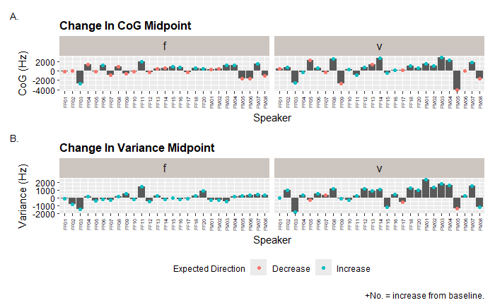

```r
wrap_plots(p.fri.f.cog, p.fri.f.sd, ncol = 1) +
  plot_layout(axis_titles = "collect",
              axes = "collect",
              guides = "collect") +
  plot_annotation(caption = "+No. = increase from baseline.",
                  tag_levels = "A",
                  tag_suffix = ".") &
  theme(plot.tag = element_text(size = 10), legend.position = "bottom", legend.direction = "horizontal", legend.title = element_text(size = 9))
```

Duration

```r
dfFr_ci %>%
  filter(Consonant %in% c("f","v")) %>%
  ggplot(aes(x = Speaker, y = cin_dur)) +
  theme_gray() +
  geom_bar(stat = "identity") +
  theme(plot.title = element_text(face = "bold", size = 12),
        plot.subtitle = element_text(size = 9),
        axis.title.x = element_text(vjust = 0.5),
        axis.title.y = element_text(vjust = 2),
        axis.text.x = element_text(size = 6, angle = 90, vjust = 0.5),
        axis.text = element_text(colour = "black"),
        strip.background = element_rect(fill = "seashell3"),
        strip.text = element_text(size = 12, vjust = 1),
        legend.title = element_text(size = 9),
        legend.position = "bottom") +
  labs(title = "Change In Duration",
       subtitle = "+No. = increase from baseline.",
       y = "Change In (ms)") +
  #geom_hline(data = dfKlem_gp, aes(yintercept = mean_cog, colour = "pink"), show.legend = FALSE) +
  geom_point(aes(colour = as.factor(dir_dur)), stat = "identity") +
  scale_colour_discrete(name="Expected Direction",
                        labels = c("Decrease", "Increase")) +
  facet_wrap(~Consonant) -> p.fri.f.dur

ggsave("fr_cin_fdur.png", p.fri.f.dur, device = agg_png, width = 12,
       height = 10, units = "cm", res = 300, scaling = 0.7)
```

### 5.4.2 Stops

Spectral Moments

```r
# COG
dfFr_ci %>%
  filter(!Consonant %in% c("f","v")) %>%
  ggplot(aes(x = Speaker, y = cin_cog)) +
  theme_gray() +
  geom_bar(stat = "identity") +
  theme(plot.title = element_text(face = "bold", size = 12),
        plot.subtitle = element_text(size = 9),
        axis.title.x = element_text(vjust = 0.5),
        axis.title.y = element_text(vjust = 2),
        axis.text.x = element_text(size = 6, angle = 90, vjust = 0.5),
        axis.text = element_text(colour = "black"),
        strip.background = element_rect(fill = "seashell3"),
        strip.text = element_text(size = 12, vjust = 1),
        legend.title = element_text(size = 9),
        legend.position = "bottom") +
  labs(title = "Stops: Change In CoG",
       #subtitle = "+No. = increase from baseline.",
       y = "CoG (Hz)") +
  #geom_hline(data = dfKlem_gp, aes(yintercept = mean_cog, colour = "pink"), show.legend = FALSE) +
  geom_point(aes(colour = as.factor(dir_cog)), stat = "identity") +
  scale_colour_discrete(name="Expected Direction",
                        labels = c("Decrease", "Increase")) +
  facet_wrap(~Consonant) +
  coord_cartesian() -> p.fri.s.cog

dfFr_ci %>%
  filter(!Consonant %in% c("f","v")) %>%
  ggplot(aes(x = Speaker, y = cin_sd)) +
  theme_gray() +
  geom_bar(stat = "identity") +
  theme(plot.title = element_text(face = "bold", size = 12),
        plot.subtitle = element_text(size = 9),
        axis.title.x = element_text(vjust = 0.5),
        axis.title.y = element_text(vjust = 2),
        axis.text.x = element_text(size = 6, angle = 90, vjust = 0.5),
        axis.text = element_text(colour = "black"),
        strip.background = element_rect(fill = "seashell3"),
        strip.text = element_text(size = 12, vjust = 1),
        legend.title = element_text(size = 9)) +
  labs(title = "Stops: Change In Variance",
       #subtitle = "+No. = increase from baseline.",
       y = "CoG (Hz)") +
  #geom_hline(data = dfKlem_gp, aes(yintercept = mean_cog, colour = "pink"), show.legend = FALSE) +
  geom_point(aes(colour = as.factor(dir_sd)), stat = "identity") +
  scale_colour_discrete(name="Expected Direction",
                        labels = c("Decrease", "Increase")) +
  facet_wrap(~Consonant) +
  coord_cartesian() -> p.fri.s.var

dfFr_ci %>%
  filter(!Consonant %in% c("f","v")) %>%
  ggplot(aes(x = Speaker, y = cin_skew)) +
  theme_gray() +
  geom_bar(stat = "identity") +
  theme(plot.title = element_text(face = "bold", size = 12),
        plot.subtitle = element_text(size = 9),
        axis.title.x = element_text(vjust = 0.5),
        axis.title.y = element_text(vjust = 2),
        axis.text.x = element_text(size = 6, angle = 90, vjust = 0.5),
        axis.text = element_text(colour = "black"),
        strip.background = element_rect(fill = "seashell3"),
        strip.text = element_text(size = 12, vjust = 1),
        legend.title = element_text(size = 9)) +
  labs(title = "Stops: Change In Skewness",
       #subtitle = "+No. = increase from baseline.",
       y = "CoG (Hz)") +
  #geom_hline(data = dfKlem_gp, aes(yintercept = mean_cog, colour = "pink"), show.legend = FALSE) +
  geom_point(aes(colour = as.factor(dir_skew)), stat = "identity") +
  scale_colour_discrete(name="Expected Direction",
                        labels = c("Decrease", "Increase")) +
  facet_wrap(~Consonant) +
  coord_cartesian() -> p.fri.s.skew

dfFr_ci %>%
  filter(!Consonant %in% c("f","v")) %>%
  ggplot(aes(x = Speaker, y = cin_kurt)) +
  theme_gray() +
  geom_bar(stat = "identity") +
  theme(plot.title = element_text(face = "bold", size = 12),
        plot.subtitle = element_text(size = 9),
        axis.title.x = element_text(vjust = 0.5),
        axis.title.y = element_text(vjust = 2),
        axis.text.x = element_text(size = 6, angle = 90, vjust = 0.5),
        axis.text = element_text(colour = "black"),
        strip.background = element_rect(fill = "seashell3"),
        strip.text = element_text(size = 12, vjust = 1),
        legend.title = element_text(size = 9)) +
  labs(title = "Stops: Change In Kurtosis",
       #subtitle = "+No. = increase from baseline.",
       y = "CoG (Hz)") +
  #geom_hline(data = dfKlem_gp, aes(yintercept = mean_cog, colour = "pink"), show.legend = FALSE) +
  geom_point(aes(colour = as.factor(dir_kurt)), stat = "identity") +
  scale_colour_discrete(name="Expected Direction",
                        labels = c("Decrease", "Increase")) +
  facet_wrap(~Consonant) +
  coord_cartesian() -> p.fri.s.kurt

ggsave("fr_cin_scog.png", p.fri.s.cog, device = agg_png, width = 12,
       height = 10, units = "cm", res = 300, scaling = 0.7)

ggsave("fr_cin_svar.png", p.fri.s.var, device = agg_png, width = 12,
       height = 10, units = "cm", res = 300, scaling = 0.7)

ggsave("fr_cin_sskew.png", p.fri.s.skew, device = agg_png, width = 12,
       height = 10, units = "cm", res = 300, scaling = 0.7)

ggsave("fr_cin_skurt.png", p.fri.s.kurt, device = agg_png, width = 12,
       height = 10, units = "cm", res = 300, scaling = 0.7)
```

Duration

```r
dfFr_ci %>%
  filter(!Consonant %in% c("f","v")) %>%
  ggplot(aes(x = Speaker, y = cin_dur)) +
  theme_gray() +
  geom_bar(stat = "identity") +
  theme(plot.title = element_text(face = "bold", size = 12),
        plot.subtitle = element_text(size = 9),
        axis.title.x = element_text(vjust = 0.5),
        axis.title.y = element_text(vjust = 2),
        axis.text.x = element_text(size = 6, angle = 90, vjust = 0.5),
        axis.text = element_text(colour = "black"),
        strip.background = element_rect(fill = "seashell3"),
        strip.text = element_text(size = 12, vjust = 1),
        legend.title = element_text(size = 9),
        legend.position = "bottom") +
  labs(title = "Stops: Change In Burst Duration",
       subtitle = "+No. = increase from baseline.",
       y = "Change In (ms)") +
  #geom_hline(data = dfKlem_gp, aes(yintercept = mean_cog, colour = "pink"), show.legend = FALSE) +
  geom_point(aes(colour = as.factor(dir_dur)), stat = "identity") +
  scale_colour_discrete(name="Expected Direction",
                        labels = c("Decrease", "Increase")) +
  facet_wrap(~Consonant) -> p.fri.s.dur

ggsave("fr_cin_sdur.png", p.fri.s.dur, device = agg_png, width = 12,
       height = 10, units = "cm", res = 300, scaling = 0.7)
```

VOT

```r
dfFr_ci %>%
  filter(!Consonant %in% c("f","v")) %>%
  ggplot(aes(x = Speaker, y = cin_vot)) +
  theme_gray() +
  geom_bar(stat = "identity") +
  theme(plot.title = element_text(face = "bold", size = 12),
        plot.subtitle = element_text(size = 9),
        axis.title.x = element_text(vjust = 0.5),
        axis.title.y = element_text(vjust = 2),
        axis.text.x = element_text(size = 6, angle = 90, vjust = 0.5),
        axis.text = element_text(colour = "black"),
        strip.background = element_rect(fill = "seashell3"),
        strip.text = element_text(size = 12, vjust = 1),
        legend.title = element_text(size = 9),
        legend.position = "bottom") +
  labs(title = "Stops: Change In VOT",
       subtitle = "+No. = increase from baseline.",
       y = "Change In (ms)") +
  #geom_hline(data = dfKlem_gp, aes(yintercept = mean_cog, colour = "pink"), show.legend = FALSE) +
  geom_point(aes(colour = as.factor(dir_vot)), stat = "identity") +
  scale_colour_discrete(name="Expected Direction",
                        labels = c("Decrease", "Increase")) +
  facet_wrap(~Consonant) -> p.fri.s.vot

ggsave("fr_cin_vot.png", p.fri.s.vot, device = agg_png, width = 12,
       height = 10, units = "cm", res = 300, scaling = 0.7)
```

## 5.5 Top Imitators

```r
df.top.prox <- data.frame()

measure.s <- quos(prox_cog, prox_sd, prox_skew, prox_kurt, prox_dur, prox_vot)
measure.f <- quos(prox_cog_mid, prox_sd_mid, prox_skew_mid, prox_kurt_mid, prox_dur)

for (m in measure.s) {
   dfTemp <- dfFr_prox %>%
    filter(!Consonant %in% c("f","v")) %>%
    arrange(!! m) %>%
    group_by(Consonant) %>%
    slice(1:5) %>%
    select(Speaker, Consonant) %>%
    mutate(Measure = quo_name(m))

  df.top.prox <- bind_rows(df.top.prox, dfTemp)
}

for (m in measure.f) {
   dfTemp <- dfFr_prox %>%
    filter(Consonant %in% c("f","v")) %>%
    arrange(!! m) %>%
    group_by(Consonant) %>%
    slice(1:5) %>%
    select(Speaker, Consonant) %>%
    mutate(Measure = quo_name(m))

  df.top.prox <- bind_rows(df.top.prox, dfTemp)
}
```

```r
# Figuring out if they moved in the correct direction and only keeping the values if they did
df.fr.ci <- dfFr_ci %>%
  group_by(Speaker, Consonant) %>%
  mutate(cor_cog = case_when(sign(dir_cog)==sign(cin_cog) ~ abs(cin_cog), TRUE ~ NA),
         cor_var = case_when(sign(dir_sd)==sign(cin_sd) ~ abs(cin_sd), TRUE ~ NA),
         cor_skew = case_when(sign(dir_skew)==sign(cin_skew) ~ abs(cin_skew), TRUE ~ NA),
         cor_kurt = case_when(sign(dir_kurt)==sign(cin_kurt) ~ abs(cin_kurt), TRUE ~ NA),
         cor_dur = case_when(sign(dir_dur)==sign(cin_dur) ~ abs(cin_dur), TRUE ~ NA),
         cor_vot = case_when(sign(dir_vot)==sign(cin_vot) ~ abs(cin_vot), TRUE ~ NA),
         cor_cog_mid = case_when(sign(dir_cog_mid)==sign(cin_cog_mid) ~ abs(cin_cog_mid), TRUE ~ NA),
         cor_var_mid = case_when(sign(dir_sd_mid)==sign(cin_sd_mid) ~ abs(cin_sd_mid), TRUE ~ NA),
         cor_skew_mid = case_when(sign(dir_skew_mid)==sign(cin_skew_mid) ~ abs(cin_skew_mid), TRUE ~ NA),
         cor_kurt_mid = case_when(sign(dir_kurt_mid)==sign(cin_kurt_mid) ~ abs(cin_kurt_mid), TRUE ~ NA)
         ) %>%
  select(Speaker, Consonant, cor_cog, cor_var, cor_skew, cor_kurt, cor_dur, cor_vot, cor_cog_mid, cor_var_mid, cor_skew_mid, cor_kurt_mid)
```

```r
# Change In - need to update change in to collect all the measures
# if dir_x and cin_x are both + or both - : if sign(x) == sign(x)
# mutate()
df.top.cin <- data.frame()

measure.s <- quos(cor_cog, cor_var, cor_skew, cor_kurt, cor_dur, cor_vot)
measure.f <- quos(cor_cog_mid, cor_var_mid, cor_skew_mid, cor_kurt_mid, cor_dur)

for (m in measure.s) {
   dfTemp <- df.fr.ci %>%
    filter(!Consonant %in% c("f","v")) %>%
    arrange(desc(!! m)) %>%
    group_by(Consonant) %>%
    slice(1:5) %>%
    select(Speaker, Consonant) %>%
    mutate(Measure = quo_name(m))

  df.top.cin <- bind_rows(df.top.cin, dfTemp)
}

for (m in measure.f) {
   dfTemp <- df.fr.ci %>%
    filter(Consonant %in% c("f","v")) %>%
    arrange(desc(!! m)) %>%
    group_by(Consonant) %>%
    slice(1:5) %>%
    select(Speaker, Consonant) %>%
    mutate(Measure = quo_name(m))

  df.top.cin <- bind_rows(df.top.cin, dfTemp)
}
```

```r
df.top.prox %>% count(Speaker, Consonant) %>% arrange(desc(n))
```

| Speaker | Consonant | n |
| --- | --- | --- |
| FM05 | t | 5 |
| FF03 | d | 4 |
| FF11 | t | 4 |
| FF15 | k | 4 |
| FM02 | t | 4 |
| FM02 | d | 4 |
| FM05 | d | 4 |
| FM07 | k | 4 |
| FF01 | v | 3 |
| FF02 | v | 3 |

[output cut: 86 more lines]

```r
df.top.prox %>% count(Speaker) %>% arrange(desc(n))
```

| Speaker | n |
| --- | --- |
| FM07 | 15 |
| FM05 | 14 |
| FM02 | 12 |
| FF15 | 9 |
| FF03 | 8 |
| FF09 | 8 |
| FF20 | 8 |
| FF10 | 7 |
| FF11 | 7 |
| FF16 | 7 |

[output cut: 17 more lines]

```r
df.top.cin %>% count(Speaker, Consonant) %>% arrange(desc(n))
```

| Speaker | Consonant | n |
| --- | --- | --- |
| FM08 | k | 6 |
| FF10 | g | 5 |
| FF01 | g | 4 |
| FF03 | d | 4 |
| FF11 | f | 4 |
| FF14 | t | 4 |
| FF17 | d | 4 |
| FF20 | g | 4 |
| FM03 | v | 4 |
| FF03 | t | 3 |

[output cut: 76 more lines]

```r
df.top.cin %>% count(Speaker) %>% arrange(desc(n))
```

| Speaker | n |
| --- | --- |
| FF09 | 14 |
| FF03 | 12 |
| FF11 | 12 |
| FM07 | 10 |
| FM08 | 10 |
| FM05 | 9 |
| FF07 | 8 |
| FF12 | 8 |
| FF20 | 8 |
| FM01 | 8 |

[output cut: 17 more lines]

# 6 Greek Production

Side by Side of the L1 French and NG Means

```r
# Bind the two frames together
df.gr.bind.fric <- bind_rows(lst(dfMGr_fric, dfFrGr_nosub), .id = "id") %>%
  mutate(id = factor(id)) %>%
  filter(!Consonant %in% c("c", "ɟ"))

df.gr.bind.stop <- bind_rows(lst(dfMGr_stop, dfFrGr_nosub), .id = "id") %>%
  mutate(id = factor(id)) %>%
  filter(Consonant %in% c("c", "ɟ"))
```

## 6.1 Fricatives

### 6.1.1 Spectral Moments

COG

```r
#Fric COG midpoint NG x L1 Fr
df.gr.bind.fric %>%
  ggplot(aes(x = Consonant, y = mean_cog_mid, fill = id)) +
  theme_gray() +
  geom_boxplot() +
  scale_y_continuous(breaks = seq(0, 15000, by = 2500)) +
  geom_point(aes(alpha = 0.05), size = 1.2, position = position_dodge(width = 0.75), show.legend = FALSE) +
  #geom_point(data = dfFrGr_nosub, aes(colour = Speaker, alpha = 0.3), show.legend = FALSE) +
  theme(plot.title = element_text(face = "bold", size = 12),
        plot.subtitle = element_text(size = 10),
        axis.text.x = element_text(size = 11),
        legend.title = element_text(size = 10),
        legend.position = "bottom") +
  labs(title = "L1 Greek Models x L1 French",
       subtitle = "Greek Fricatives: Mean CoG Midpoint",
       y = "Mean CoG (Hz)") +
  scale_fill_discrete(name="Speakers:", labels = c("L1 French", "L1 Greek")) +
  coord_cartesian() -> p.gr.side.cog

ggsave("l2gr_side_cog.png", p.gr.side.cog, device = agg_png, width = 12,
       height = 8, units = "cm", res = 300, scaling = 0.7)
```

Variance

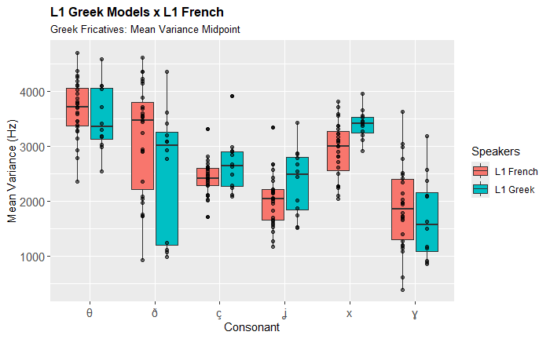

```r
#Fric COG midpoint NG x L1 Fr
df.gr.bind.fric %>%
  ggplot(aes(x = Consonant, y = mean_sd_mid, fill = id)) +
  theme_gray() +
  geom_boxplot() +
  geom_point(aes(alpha = 0.05), position = position_dodge(width = 0.75), show.legend = FALSE) +
  #geom_point(data = dfFrGr_nosub, aes(colour = Speaker, alpha = 0.3), show.legend = FALSE) +
  theme(plot.title = element_text(face = "bold", size = 12),
        plot.subtitle = element_text(size = 10),
        axis.text = element_text(size = 11)) +
  labs(title = "L1 Greek Models x L1 French",
       subtitle = "Greek Fricatives: Mean Variance Midpoint",
       y = "Mean Variance (Hz)") +
  scale_fill_discrete(name="Speakers", labels = c("L1 French", "L1 Greek"))
```

Skewness

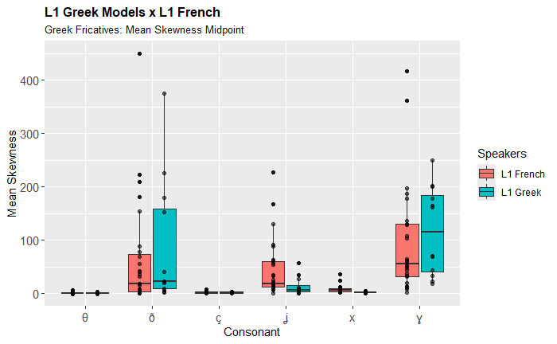

```r
#Fric COG midpoint NG x L1 Fr
df.gr.bind.fric %>%
  ggplot(aes(x = Consonant, y = mean_skew_mid, fill = id)) +
  theme_gray() +
  geom_boxplot() +
  geom_point(aes(alpha = 0.05), position = position_dodge(width = 0.75), show.legend = FALSE) +
  #geom_point(data = dfFrGr_nosub, aes(colour = Speaker, alpha = 0.3), show.legend = FALSE) +
  theme(plot.title = element_text(face = "bold", size = 12),
        plot.subtitle = element_text(size = 10),
        axis.text = element_text(size = 11)) +
  labs(title = "L1 Greek Models x L1 French",
       subtitle = "Greek Fricatives: Mean Skewness Midpoint",
       y = "Mean Skewness") +
  scale_fill_discrete(name="Speakers", labels = c("L1 French", "L1 Greek"))
```

Kurtosis

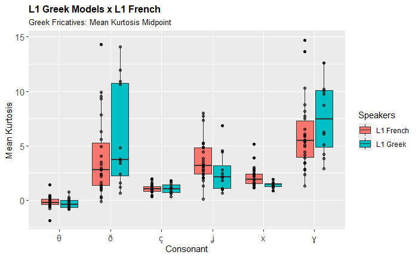

```r
#Fric COG midpoint NG x L1 Fr
df.gr.bind.fric %>%
  ggplot(aes(x = Consonant, y = mean_kurt_mid, fill = id)) +
  theme_gray() +
  geom_boxplot() +
  geom_point(aes(alpha = 0.05), position = position_dodge(width = 0.75), show.legend = FALSE) +
  #geom_point(data = dfFrGr_nosub, aes(colour = Speaker, alpha = 0.3), show.legend = FALSE) +
  theme(plot.title = element_text(face = "bold", size = 12),
        plot.subtitle = element_text(size = 10),
        axis.text = element_text(size = 11)) +
  labs(title = "L1 Greek Models x L1 French",
       subtitle = "Greek Fricatives: Mean Kurtosis Midpoint",
       y = "Mean Kurtosis") +
  scale_fill_discrete(name="Speakers", labels = c("L1 French", "L1 Greek"))
```

### 6.1.2 Duration

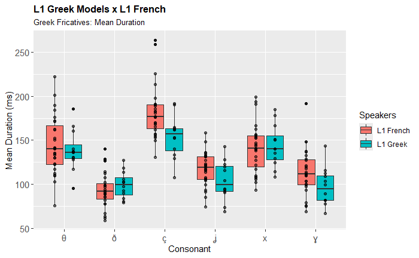

```r
#Fric COG midpoint NG x L1 Fr
df.gr.bind.fric %>%
  ggplot(aes(x = Consonant, y = mean_dur, fill = id)) +
  theme_gray() +
  geom_boxplot() +
  geom_point(aes(alpha = 0.05), position = position_dodge(width = 0.75), show.legend = FALSE) +
  #geom_point(data = dfFrGr_nosub, aes(colour = Speaker, alpha = 0.3), show.legend = FALSE) +
  theme(plot.title = element_text(face = "bold", size = 12),
        plot.subtitle = element_text(size = 10),
        axis.text = element_text(size = 11)) +
  labs(title = "L1 Greek Models x L1 French",
       subtitle = "Greek Fricatives: Mean Duration",
       y = "Mean Duration (ms)") +
  scale_fill_discrete(name="Speakers", labels = c("L1 French", "L1 Greek"))
```

## 6.2 Stops

### 6.2.1 Spectral Moments

COG

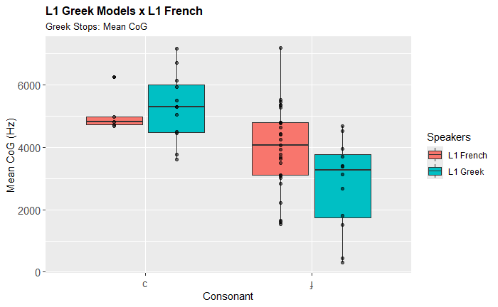

```r
#Fric COG midpoint NG x L1 Fr
df.gr.bind.stop %>%
  ggplot(aes(x = Consonant, y = mean_cog, fill = id)) +
  theme_gray() +
  geom_boxplot() +
  geom_point(aes(alpha = 0.05), position = position_dodge(width = 0.75), show.legend = FALSE) +
  #geom_point(data = dfFrGr_nosub, aes(colour = Speaker, alpha = 0.3), show.legend = FALSE) +
  theme(plot.title = element_text(face = "bold", size = 12),
        plot.subtitle = element_text(size = 10),
        axis.text = element_text(size = 11)) +
  labs(title = "L1 Greek Models x L1 French",
       subtitle = "Greek Stops: Mean CoG",
       y = "Mean CoG (Hz)") +
  scale_fill_discrete(name="Speakers", labels = c("L1 French", "L1 Greek"))
```

Variance

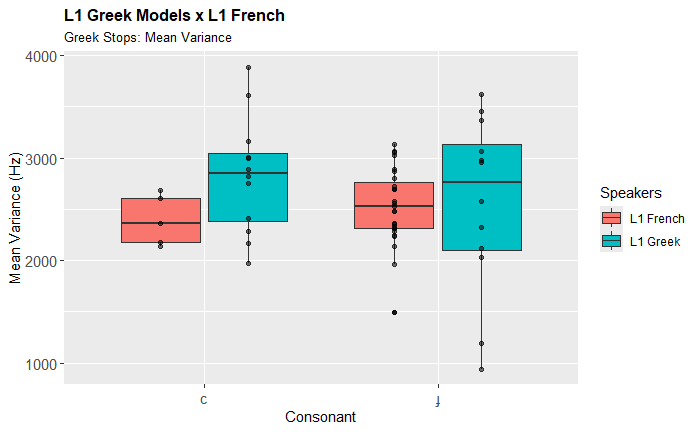

```r
#Fric COG midpoint NG x L1 Fr
df.gr.bind.stop %>%
  ggplot(aes(x = Consonant, y = mean_sd, fill = id)) +
  theme_gray() +
  geom_boxplot() +
  geom_point(aes(alpha = 0.05), position = position_dodge(width = 0.75), show.legend = FALSE) +
  #geom_point(data = dfFrGr_nosub, aes(colour = Speaker, alpha = 0.3), show.legend = FALSE) +
  theme(plot.title = element_text(face = "bold", size = 12),
        plot.subtitle = element_text(size = 10),
        axis.text = element_text(size = 11)) +
  labs(title = "L1 Greek Models x L1 French",
       subtitle = "Greek Stops: Mean Variance",
       y = "Mean Variance (Hz)") +
  scale_fill_discrete(name="Speakers", labels = c("L1 French", "L1 Greek"))
```

Skewness

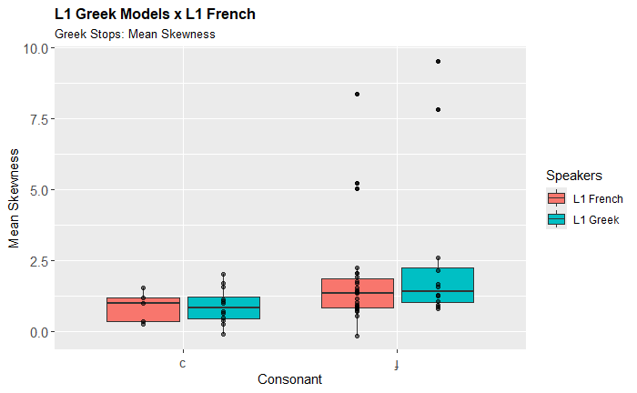

```r
#Fric COG midpoint NG x L1 Fr
df.gr.bind.stop %>%
  ggplot(aes(x = Consonant, y = mean_skew, fill = id)) +
  theme_gray() +
  geom_boxplot() +
  geom_point(aes(alpha = 0.05), position = position_dodge(width = 0.75), show.legend = FALSE) +
  #geom_point(data = dfFrGr_nosub, aes(colour = Speaker, alpha = 0.3), show.legend = FALSE) +
  theme(plot.title = element_text(face = "bold", size = 12),
        plot.subtitle = element_text(size = 10),
        axis.text = element_text(size = 11)) +
  labs(title = "L1 Greek Models x L1 French",
       subtitle = "Greek Stops: Mean Skewness",
       y = "Mean Skewness") +
  scale_fill_discrete(name="Speakers", labels = c("L1 French", "L1 Greek"))
```

Kurtosis

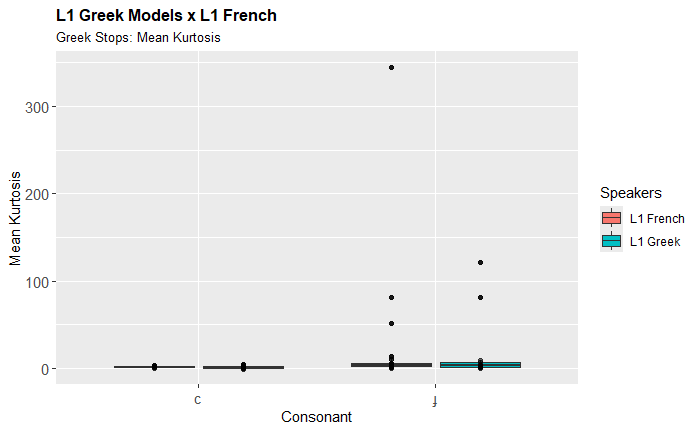

```r
#Fric COG midpoint NG x L1 Fr
df.gr.bind.stop %>%
  ggplot(aes(x = Consonant, y = mean_kurt, fill = id)) +
  theme_gray() +
  geom_boxplot() +
  geom_point(aes(alpha = 0.05), position = position_dodge(width = 0.75), show.legend = FALSE) +
  #geom_point(data = dfFrGr_nosub, aes(colour = Speaker, alpha = 0.3), show.legend = FALSE) +
  theme(plot.title = element_text(face = "bold", size = 12),
        plot.subtitle = element_text(size = 10),
        axis.text = element_text(size = 11)) +
  labs(title = "L1 Greek Models x L1 French",
       subtitle = "Greek Stops: Mean Kurtosis",
       y = "Mean Kurtosis") +
  scale_fill_discrete(name="Speakers", labels = c("L1 French", "L1 Greek"))
```

### 6.2.2 Duration

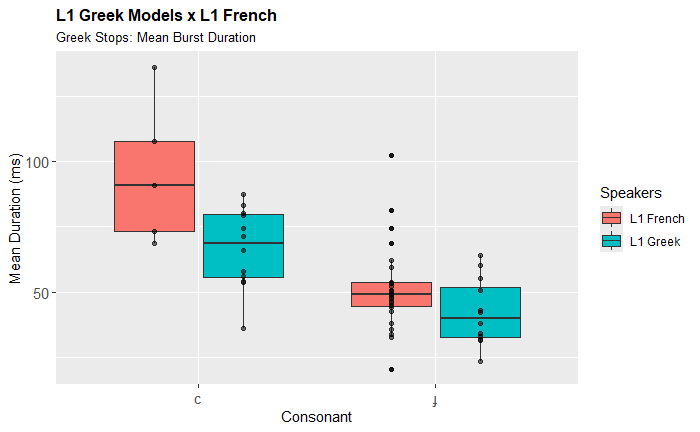

```r
#Fric COG midpoint NG x L1 Fr
df.gr.bind.stop %>%
  ggplot(aes(x = Consonant, y = mean_dur, fill = id)) +
  theme_gray() +
  geom_boxplot() +
  geom_point(aes(alpha = 0.05), position = position_dodge(width = 0.75), show.legend = FALSE) +
  #geom_point(data = dfFrGr_nosub, aes(colour = Speaker, alpha = 0.3), show.legend = FALSE) +
  theme(plot.title = element_text(face = "bold", size = 12),
        plot.subtitle = element_text(size = 10),
        axis.text = element_text(size = 11)) +
  labs(title = "L1 Greek Models x L1 French",
       subtitle = "Greek Stops: Mean Burst Duration",
       y = "Mean Duration (ms)") +
  scale_fill_discrete(name="Speakers", labels = c("L1 French", "L1 Greek"))
```

### 6.2.3 VOT

```r
#Fric COG midpoint NG x L1 Fr
df.gr.bind.stop %>%
  ggplot(aes(x = Consonant, y = mean_vot, fill = id)) +
  theme_gray() +
  geom_boxplot(show.legend = FALSE) +
  geom_point(aes(alpha = 0.05), position = position_dodge(width = 0.75), show.legend = FALSE) +
  #geom_point(data = dfFrGr_nosub, aes(colour = Speaker, alpha = 0.3), show.legend = FALSE) +
  theme(plot.title = element_text(face = "bold", size = 12),
        plot.subtitle = element_text(size = 10),
        axis.text = element_text(size = 11)) +
  labs(title = "L1 Greek Models x L1 French",
       subtitle = "Greek Stops: Mean VOT",
       y = "Mean VOT (ms)") +
  scale_fill_discrete(name="Speakers", labels = c("L1 French", "L1 Greek")) +
  coord_cartesian() -> l2gr.vot
```

## 6.3 Proximity

Excludes substitutions.

### 6.3.1 Fricatives

Spectral Moments

```r
dfFrGr_prox %>%
  filter(!Consonant %in% c("c","ɟ")) %>%
  ggplot(aes(x = Consonant, y = prox_cog_mid)) +
  theme_gray() +
  geom_boxplot(width = 0.5) +
  geom_point(aes(colour = "pink", alpha = 0.3), size = 1.2, stat = "identity", show.legend = FALSE) +
  theme(plot.title = element_text(face = "bold", size = 12),
        plot.subtitle = element_text(size = 8),
        axis.title.x = element_text(vjust = 0.5),
        axis.title.y = element_text(vjust = 2),
        axis.text.x = element_text(size = 11),
        axis.text.y = element_text(size = 10),
        axis.text = element_text(colour = "black")) +
  labs(title = "Proximity Mean COG",
       #subtitle = "Closer to zero is better.",
       y = "Proximity (Hz)") +
  coord_cartesian() -> p.l2gr.f.cog
```

Making a wrapped plot

```r
p.l2gr.f.all <- wrap_plots(p.l2gr.f.cog, p.l2gr.f.var, p.l2gr.f.skew, p.l2gr.f.kurt) +
  plot_layout(axis_titles = "collect", axes = "collect_x") +
  plot_annotation(caption = "Closer to zero is better.",
                  tag_levels = "A",
                  tag_suffix = ".") &
  theme(plot.tag = element_text(size = 10))
```

[output not shown]

Variance

Skewness

Kurtosis

Duration

### 6.3.2 Stops

Spectral Moments

Variance

Skewness

Kurtosis

Making a wrapped plot

Duration

VOT

## 6.4 Change In

Could only really to it for tdk

## 6.5 Top Imitators

```r
df.top.gr.prox <- data.frame()

measure.s <- quos(prox_cog, prox_sd, prox_skew, prox_kurt, prox_dur, prox_vot)
measure.f <- quos(prox_cog_mid, prox_sd_mid, prox_skew_mid, prox_kurt_mid, prox_dur)

for (m in measure.s) {
   dfTemp <- dfFrGr_prox %>%
    filter(!Consonant %in% c("f","v")) %>%
    arrange(!! m) %>%
    group_by(Consonant) %>%
    slice(1:5) %>%
    select(Speaker, Consonant) %>%
    mutate(Measure = quo_name(m))

  df.top.gr.prox <- bind_rows(df.top.gr.prox, dfTemp)
}

for (m in measure.f) {
   dfTemp <- dfFrGr_prox %>%
    filter(Consonant %in% c("f","v")) %>%
    arrange(!! m) %>%
    group_by(Consonant) %>%
    slice(1:5) %>%
    select(Speaker, Consonant) %>%
    mutate(Measure = quo_name(m))

  df.top.gr.prox <- bind_rows(df.top.gr.prox, dfTemp)
}
```

```r
df.top.gr.prox %>% count(Speaker, Consonant) %>% arrange(desc(n))
```

| Speaker | Consonant | n |
| --- | --- | --- |
| FF1 | c | 6 |
| FF2 | c | 6 |
| FM1 | c | 6 |
| FM2 | c | 6 |
| SF1 | c | 6 |
| FM2 | ɟ | 5 |
| FF1 | x | 4 |
| FF17 | ɣ | 4 |
| FF2 | θ | 4 |
| FF20 | ç | 4 |

[output cut: 116 more lines]

```r
df.top.gr.prox %>% count(Speaker) %>% arrange(desc(n))
```

| Speaker | n |
| --- | --- |
| FM2 | 22 |
| FM1 | 20 |
| FF1 | 18 |
| FF2 | 16 |
| SF1 | 16 |
| FF9 | 15 |
| FM7 | 12 |
| FF20 | 10 |
| FF5 | 10 |
| FM5 | 10 |

[output cut: 17 more lines]